# Practicum 2

## Intro to Machine Learning And Data Mining

### Submitted by: *Rajarshi Choudhury*

#### Problem1:

##### Question 1a: Download the data set Census Income Data for Adults along with its explanation. Note that the data file does not contain header names; you may wish to add those. The description of each column can be found in the data set explanation.

Let’s first download the dataset, and give the column names based on the given description:

```r
adult_data <- read.csv("http://archive.ics.uci.edu/ml/machine-learning-databases/adult/adult.data",header = FALSE,stringsAsFactors = FALSE,col.names=c("Age","Workclass","Fnlwgt","Education","Educationnum","MaritalStatus","Occupation","Relationship","Race","Sex","Capital-Gain","CapitalLoss","HoursPerWeek","NativeCountry", "Sal")) #Specifying column name based on description of data given in data set explanation.

#variable class is represented here as sal, so as not to avoid with any inbuilt fuction/term "class"

adult_data[1:10,]
```

```
##    Age         Workclass Fnlwgt  Education Educationnum
## 1   39         State-gov  77516  Bachelors           13
## 2   50  Self-emp-not-inc  83311  Bachelors           13
## 3   38           Private 215646    HS-grad            9
## 4   53           Private 234721       11th            7
## 5   28           Private 338409  Bachelors           13
## 6   37           Private 284582    Masters           14
## 7   49           Private 160187        9th            5
## 8   52  Self-emp-not-inc 209642    HS-grad            9
## 9   31           Private  45781    Masters           14
## 10  42           Private 159449  Bachelors           13
##             MaritalStatus         Occupation   Relationship   Race     Sex
## 1           Never-married       Adm-clerical  Not-in-family  White    Male
## 2      Married-civ-spouse    Exec-managerial        Husband  White    Male
## 3                Divorced  Handlers-cleaners  Not-in-family  White    Male
```

[output cut: 18 more lines]

##### Question 1b: Explore the data set as you see fit and that allows you to get a sense of the data and get comfortable with it. Is there distributional skew in any of the features? Is there a need to apply a transform?

Lets first try to get a hint of data:

```r
summary(adult_data)
```

```
##       Age         Workclass             Fnlwgt         Education
##  Min.   :17.00   Length:32561       Min.   :  12285   Length:32561
##  1st Qu.:28.00   Class :character   1st Qu.: 117827   Class :character
##  Median :37.00   Mode  :character   Median : 178356   Mode  :character
##  Mean   :38.58                      Mean   : 189778
##  3rd Qu.:48.00                      3rd Qu.: 237051
##  Max.   :90.00                      Max.   :1484705
##   Educationnum   MaritalStatus       Occupation        Relationship
##  Min.   : 1.00   Length:32561       Length:32561       Length:32561
##  1st Qu.: 9.00   Class :character   Class :character   Class :character
##  Median :10.00   Mode  :character   Mode  :character   Mode  :character
##  Mean   :10.08
##  3rd Qu.:12.00
##  Max.   :16.00
##      Race               Sex             Capital.Gain    CapitalLoss
##  Length:32561       Length:32561       Min.   :    0   Min.   :   0.0
##  Class :character   Class :character   1st Qu.:    0   1st Qu.:   0.0
##  Mode  :character   Mode  :character   Median :    0   Median :   0.0
##                                        Mean   : 1078   Mean   :  87.3
##                                        3rd Qu.:    0   3rd Qu.:   0.0
##                                        Max.   :99999   Max.   :4356.0
##   HoursPerWeek   NativeCountry          Sal
##  Min.   : 1.00   Length:32561       Length:32561
##  1st Qu.:40.00   Class :character   Class :character
##  Median :40.00   Mode  :character   Mode  :character
##  Mean   :40.44
##  3rd Qu.:45.00
##  Max.   :99.00
```

```r
anyNA(adult_data)
```

```
## [1] FALSE
```

Now the code shows that there are no NA values. Lets go through the entire dataset visually

```r
#view(adult_data) #This code is INTENTIONALLY COMMENTED to maintain cleanliness of the data.
```

We see that while there is no NA present, there are missing values which are filled with “?” value.

Lets convert them to NA values:

```r
adult_data[adult_data == " ?"] <- NA
#Lets see if there are any NA values now
anyNA(adult_data)
```

```
## [1] TRUE
```

So we have missing values. Lets see which colums have missing values:

```r
colnames(adult_data)[colSums(is.na(adult_data)) > 0]
```

```
## [1] "Workclass"     "Occupation"    "NativeCountry"
```

So there are missing values in these three columns: Workclass, Occupation, NativeCountry. All the three are categorical variables. As such the modes of imputation that we can use here are mode, knn, etc. Here we will be using mode to impute the values. This is taken after taking into consideration that most of the mode values are in large category, and makes sense to use mode.

Lets first define the mode function:

```r
mode <- function(x) {
  uniqv <- unique(x)
  uniqv[which.max(tabulate(match(x, uniqv)))]
}
```

Lets first determine the mode of column: Workclass

```r
x <- adult_data$Workclass
wcs.m <- mode(x)#calculating mode
x[is.na(x)] <- wcs.m
wcs.m #mode of Workclass
```

```
## [1] " Private"
```

```r
#Is there any missing values now?
anyNA(x)
```

```
## [1] FALSE
```

Now lets determine the mode of column: Occupation

```r
y <- adult_data$Occupation
occn.m <- mode(y)#calculating mode
y[is.na(y)] <- occn.m
occn.m #mode of Occupation
```

```
## [1] " Prof-specialty"
```

```r
#Is there any missing values now?
anyNA(y)
```

```
## [1] FALSE
```

Finally we will determine the mode of Native Country

```r
z <- adult_data$NativeCountry
nc.m <- mode(z) #calculating mode
z[is.na(z)] <- nc.m
nc.m #mode of Native Country
```

```
## [1] " United-States"
```

```r
#Is there any missing values now?
anyNA(z)
```

```
## [1] FALSE
```

So now we take the values of mode and put it in the missing values:

```r
adult_data$Workclass[which(is.na(adult_data$Workclass))] <- wcs.m
adult_data$Occupation[which(is.na(adult_data$Occupation))] <- occn.m
adult_data$NativeCountry[which(is.na(adult_data$NativeCountry))] <- nc.m
```

Is there any missing data remaining?

```r
anyNA(adult_data)
```

```
## [1] FALSE
```

So we finally have all the missing data imputed.

Lets find the skewness, if present, for our data. We will use pairs.panel for the same.

```r
library(psych)
```

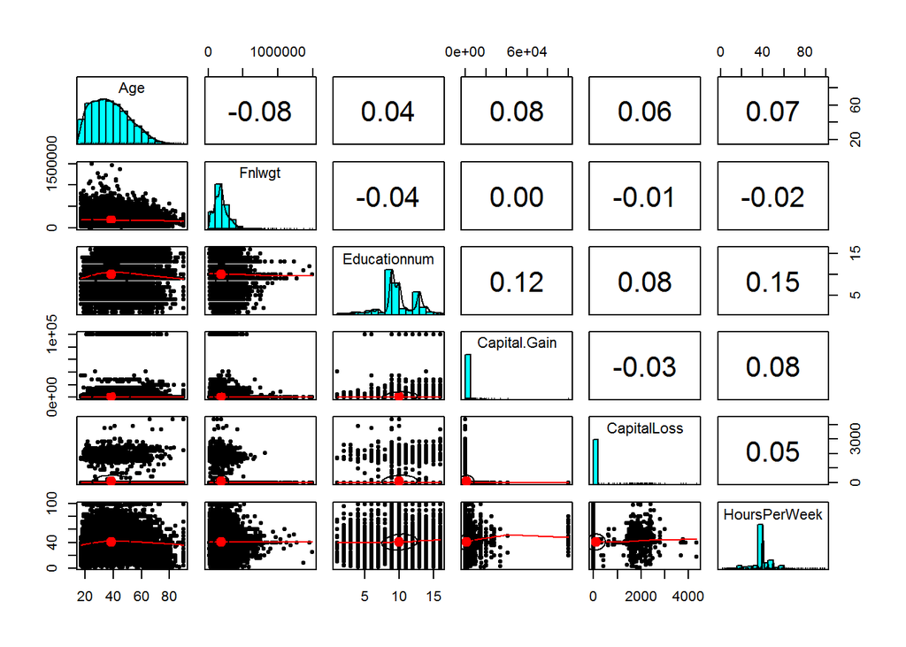

```r
pairs.panels(adult_data[c(1,3, 5, 11,12,13)]) #Using pairs.panel
```

From here, we see that there is shewness present in the data. However, in this case, the skewness dont affect the calculation. So we wont be removing outliers in this case.

##### 1c: Create a frequency and then a likelihood table for the categorical features in the data set. Build your own Naive Bayes classifier for those features.

Here we will need to define a frequency and likelihood table for the categorical variable. We will first create the frequency and likelihood table based on the binomial class variable, which is the sal column in the data.

Now first we will need to create a table format for all the categorical variables. We develop it using the below code:

```r
l1 <- table(adult_data$Workclass, adult_data$Sal)
l2 <- table(adult_data$Education, adult_data$Sal)
l3 <- table(adult_data$MaritalStatus, adult_data$Sal)
l4 <- table(adult_data$Occupation, adult_data$Sal)
l5 <- table(adult_data$Relationship, adult_data$Sal)
l6 <- table(adult_data$Race, adult_data$Sal)
l7 <- table(adult_data$Sex, adult_data$Sal)
l8 <- table(adult_data$NativeCountry, adult_data$Sal)

#Convering to matrix format from table format:
k1 <- unclass(l1)
k2 <- unclass(l2)
k3 <- unclass(l3)
k4 <- unclass(l4)
k5 <- unclass(l5)
k6 <- unclass(l6)
k7 <- unclass(l7)
k8 <- unclass(l8)
```

Lets see the frequency table one-by-one:

Frequency table for Workclass:

```r
k1
```

```
##
##                      <=50K  >50K
##    Federal-gov         589   371
##    Local-gov          1476   617
##    Never-worked          7     0
##    Private           19378  5154
##    Self-emp-inc        494   622
##    Self-emp-not-inc   1817   724
##    State-gov           945   353
##    Without-pay          14     0
```

Frequency table for Education:

```r
k2
```

```
##
##                  <=50K  >50K
##    10th            871    62
##    11th           1115    60
##    12th            400    33
##    1st-4th         162     6
##    5th-6th         317    16
##    7th-8th         606    40
##    9th             487    27
##    Assoc-acdm      802   265
##    Assoc-voc      1021   361
##    Bachelors      3134  2221
##    Doctorate       107   306
##    HS-grad        8826  1675
##    Masters         764   959
##    Preschool        51     0
##    Prof-school     153   423
##    Some-college   5904  1387
```

Frequency table for Marital Status:

```r
k3
```

```
##
##                           <=50K  >50K
##    Divorced                3980   463
##    Married-AF-spouse         13    10
##    Married-civ-spouse      8284  6692
##    Married-spouse-absent    384    34
##    Never-married          10192   491
##    Separated                959    66
##    Widowed                  908    85
```

Frequency table for Occupation:

```r
k4
```

```
##
##                       <=50K  >50K
##    Adm-clerical        3263   507
##    Armed-Forces           8     1
##    Craft-repair        3170   929
##    Exec-managerial     2098  1968
##    Farming-fishing      879   115
##    Handlers-cleaners   1284    86
##    Machine-op-inspct   1752   250
##    Other-service       3158   137
##    Priv-house-serv      148     1
##    Prof-specialty      3933  2050
##    Protective-serv      438   211
##    Sales               2667   983
##    Tech-support         645   283
##    Transport-moving    1277   320
```

Frequency table for Relationship:

```r
k5
```

```
##
##                    <=50K  >50K
##    Husband          7275  5918
##    Not-in-family    7449   856
##    Other-relative    944    37
##    Own-child        5001    67
##    Unmarried        3228   218
##    Wife              823   745
```

Frequency table for Race:

```r
k6
```

```
##
##                        <=50K  >50K
##    Amer-Indian-Eskimo    275    36
##    Asian-Pac-Islander    763   276
##    Black                2737   387
##    Other                 246    25
##    White               20699  7117
```

Frequency table for Sex:

```r
k7
```

```
##
##            <=50K  >50K
##    Female   9592  1179
##    Male    15128  6662
```

```r
k8
```

```
##
##                                <=50K  >50K
##    Cambodia                       12     7
##    Canada                         82    39
##    China                          55    20
##    Columbia                       57     2
##    Cuba                           70    25
##    Dominican-Republic             68     2
##    Ecuador                        24     4
##    El-Salvador                    97     9
##    England                        60    30
##    France                         17    12
##    Germany                        93    44
##    Greece                         21     8
##    Guatemala                      61     3
##    Haiti                          40     4
##    Holand-Netherlands              1     0
##    Honduras                       12     1
##    Hong                           14     6
##    Hungary                        10     3
##    India                          60    40
##    Iran                           25    18
##    Ireland                        19     5
##    Italy                          48    25
##    Jamaica                        71    10
##    Japan                          38    24
##    Laos                           16     2
##    Mexico                        610    33
##    Nicaragua                      32     2
##    Outlying-US(Guam-USVI-etc)     14     0
##    Peru                           29     2
##    Philippines                   137    61
##    Poland                         48    12
##    Portugal                       33     4
##    Puerto-Rico                   102    12
##    Scotland                        9     3
##    South                          64    16
##    Taiwan                         31    20
##    Thailand                       15     3
##    Trinadad&Tobago                17     2
##    United-States               22436  7317
##    Vietnam                        62     5
##    Yugoslavia                     10     6
```

Now we will develop the likelihood table. So here there we wil be two types of likelihood. One likelihood that the binomial class is >50K, and the other, the binomial class is <50K. Lets first create a couple of functions:

```r
#This function calculates the likeliness of the table.
likeliness_calc <- function(x, tem, lem) #The fuction imports three variables: x, tem, lem
{
  dof <- x #create a separate dataframe from x
  j <- nrow(x) #calculates number of rows of x
  for (i in 1:j)
  {
    tem[i] <- x[i,2]/sum(x[i,1],x[i,2]) #calculate likeliness given binomial class variable >50K
    lem[i] <- x[i,1]/sum(x[i,1],x[i,2]) #calculate likeliness given binomial class variable <50K
  }

  dof <- cbind(dof, tem, lem) #binds the initial data frame with the calculated likelihoods
  colnames(dof)[3] <- c("Likelihood_>50K") #changing name of the 3rd column corresponding to the likelihood of sal class >50K
  colnames(dof)[4] <- c("Likelihood_<50K") #changing name of the 4th column corresponding to the likelihood of sal class <50K
  print(dof) #printing the data-frame
}


#This function is first called when we need to predict the likelihood
likeliness <- function(x) #takes the value of x, in this case, usually a matrix
{
  tem <- numeric(nrow(x)) #define a variable calculating number of rows of x
  lem <- numeric(nrow(x)) #define another variable calculating number of rows of x
  likeliness_calc(x, tem, lem) #passing the x, as well as two other created variable to the likeliness_calc() function
}
```

Now lets see the likelihood table of each category based on the frequency table earlier calculated.

Likelihood table for Workclass:

```r
Workclass1 <- likeliness(k1) #Here the likelihood table will be automatically printed and we dont need to implicitly call the function. This is because whenevr we call likelines, it internally calls likeliness_calc(), which prints the new matrix.
```

```
##                    <=50K  >50K Likelihood_>50K Likelihood_<50K
##  Federal-gov         589   371       0.3864583       0.6135417
##  Local-gov          1476   617       0.2947922       0.7052078
##  Never-worked          7     0       0.0000000       1.0000000
##  Private           19378  5154       0.2100929       0.7899071
##  Self-emp-inc        494   622       0.5573477       0.4426523
##  Self-emp-not-inc   1817   724       0.2849272       0.7150728
##  State-gov           945   353       0.2719569       0.7280431
##  Without-pay          14     0       0.0000000       1.0000000
```

Likelihood table for Education:

```r
Education1 <- likeliness(k2)
```

```
##                <=50K  >50K Likelihood_>50K Likelihood_<50K
##  10th            871    62      0.06645230       0.9335477
##  11th           1115    60      0.05106383       0.9489362
##  12th            400    33      0.07621247       0.9237875
##  1st-4th         162     6      0.03571429       0.9642857
##  5th-6th         317    16      0.04804805       0.9519520
##  7th-8th         606    40      0.06191950       0.9380805
##  9th             487    27      0.05252918       0.9474708
##  Assoc-acdm      802   265      0.24835989       0.7516401
##  Assoc-voc      1021   361      0.26121563       0.7387844
##  Bachelors      3134  2221      0.41475257       0.5852474
##  Doctorate       107   306      0.74092010       0.2590799
##  HS-grad        8826  1675      0.15950862       0.8404914
##  Masters         764   959      0.55658735       0.4434127
##  Preschool        51     0      0.00000000       1.0000000
##  Prof-school     153   423      0.73437500       0.2656250
##  Some-college   5904  1387      0.19023454       0.8097655
```

Likelihood table for Marital Status:

```r
MaritalStatus1 <- likeliness(k3)
```

```
##                         <=50K  >50K Likelihood_>50K Likelihood_<50K
##  Divorced                3980   463      0.10420887       0.8957911
##  Married-AF-spouse         13    10      0.43478261       0.5652174
##  Married-civ-spouse      8284  6692      0.44684829       0.5531517
##  Married-spouse-absent    384    34      0.08133971       0.9186603
##  Never-married          10192   491      0.04596087       0.9540391
##  Separated                959    66      0.06439024       0.9356098
##  Widowed                  908    85      0.08559919       0.9144008
```

Likelihood table for Occupation:

```r
Occupation1 <- likeliness(k4)
```

```
##                     <=50K  >50K Likelihood_>50K Likelihood_<50K
##  Adm-clerical        3263   507     0.134482759       0.8655172
##  Armed-Forces           8     1     0.111111111       0.8888889
##  Craft-repair        3170   929     0.226640644       0.7733594
##  Exec-managerial     2098  1968     0.484013773       0.5159862
##  Farming-fishing      879   115     0.115694165       0.8843058
##  Handlers-cleaners   1284    86     0.062773723       0.9372263
##  Machine-op-inspct   1752   250     0.124875125       0.8751249
##  Other-service       3158   137     0.041578149       0.9584219
##  Priv-house-serv      148     1     0.006711409       0.9932886
##  Prof-specialty      3933  2050     0.342637473       0.6573625
##  Protective-serv      438   211     0.325115562       0.6748844
##  Sales               2667   983     0.269315068       0.7306849
##  Tech-support         645   283     0.304956897       0.6950431
##  Transport-moving    1277   320     0.200375704       0.7996243
```

Likelihood table for Relationship:

```r
Relationship1 <- likeliness(k5)
```

```
##                  <=50K  >50K Likelihood_>50K Likelihood_<50K
##  Husband          7275  5918      0.44857121       0.5514288
##  Not-in-family    7449   856      0.10307044       0.8969296
##  Other-relative    944    37      0.03771662       0.9622834
##  Own-child        5001    67      0.01322021       0.9867798
##  Unmarried        3228   218      0.06326175       0.9367382
##  Wife              823   745      0.47512755       0.5248724
```

Likelihood table for Race:

```r
Race1 <- likeliness(k6)
```

```
##                      <=50K  >50K Likelihood_>50K Likelihood_<50K
##  Amer-Indian-Eskimo    275    36      0.11575563       0.8842444
##  Asian-Pac-Islander    763   276      0.26564004       0.7343600
##  Black                2737   387      0.12387964       0.8761204
##  Other                 246    25      0.09225092       0.9077491
##  White               20699  7117      0.25585994       0.7441401
```

Likelihood table for Sex:

```r
Sex1 <- likeliness(k7)
```

```
##          <=50K  >50K Likelihood_>50K Likelihood_<50K
##  Female   9592  1179       0.1094606       0.8905394
##  Male    15128  6662       0.3057366       0.6942634
```

Likelihood table for Native Country:

```r
NativeCountry1 <- likeliness(k8)
```

```
##                              <=50K  >50K Likelihood_>50K Likelihood_<50K
##  Cambodia                       12     7      0.36842105       0.6315789
##  Canada                         82    39      0.32231405       0.6776860
##  China                          55    20      0.26666667       0.7333333
##  Columbia                       57     2      0.03389831       0.9661017
##  Cuba                           70    25      0.26315789       0.7368421
##  Dominican-Republic             68     2      0.02857143       0.9714286
##  Ecuador                        24     4      0.14285714       0.8571429
##  El-Salvador                    97     9      0.08490566       0.9150943
##  England                        60    30      0.33333333       0.6666667
##  France                         17    12      0.41379310       0.5862069
##  Germany                        93    44      0.32116788       0.6788321
##  Greece                         21     8      0.27586207       0.7241379
##  Guatemala                      61     3      0.04687500       0.9531250
##  Haiti                          40     4      0.09090909       0.9090909
##  Holand-Netherlands              1     0      0.00000000       1.0000000
##  Honduras                       12     1      0.07692308       0.9230769
##  Hong                           14     6      0.30000000       0.7000000
##  Hungary                        10     3      0.23076923       0.7692308
##  India                          60    40      0.40000000       0.6000000
##  Iran                           25    18      0.41860465       0.5813953
##  Ireland                        19     5      0.20833333       0.7916667
##  Italy                          48    25      0.34246575       0.6575342
##  Jamaica                        71    10      0.12345679       0.8765432
##  Japan                          38    24      0.38709677       0.6129032
##  Laos                           16     2      0.11111111       0.8888889
##  Mexico                        610    33      0.05132193       0.9486781
##  Nicaragua                      32     2      0.05882353       0.9411765
##  Outlying-US(Guam-USVI-etc)     14     0      0.00000000       1.0000000
##  Peru                           29     2      0.06451613       0.9354839
##  Philippines                   137    61      0.30808081       0.6919192
##  Poland                         48    12      0.20000000       0.8000000
##  Portugal                       33     4      0.10810811       0.8918919
##  Puerto-Rico                   102    12      0.10526316       0.8947368
##  Scotland                        9     3      0.25000000       0.7500000
##  South                          64    16      0.20000000       0.8000000
##  Taiwan                         31    20      0.39215686       0.6078431
##  Thailand                       15     3      0.16666667       0.8333333
##  Trinadad&Tobago                17     2      0.10526316       0.8947368
##  United-States               22436  7317      0.24592478       0.7540752
##  Vietnam                        62     5      0.07462687       0.9253731
##  Yugoslavia                     10     6      0.37500000       0.6250000
```

Now here we can calculate as many frequency and likelihood tables as we want, based on other class variables. The reason binomial class variable “sal” is taken is because we can directly use the above codes in problem 1d.

For developing our naive bayes algorithm, we will multiply the likelihood of the category variables with the probability of the varible we take as the factor on which we are creating our algorithm. The naive bayes algorithm for class prediction using a few feature variables is developed in problem 1d, and not shown here to remove duplication.

##### Problem 1d: Predict the binomial class membership for a white male adult who is a federal government worker with a bachelors degree who immigrated from Ireland. Ignore any other features in your model. You must build your own Naive Bayes Classifier – you may not use a package.

Now we need to understand how our algorithm for naive bayes works. Here we need to determine in which class the persson will probably lie.

So here basically we are calculating P(>50K|White+Male+Federal-gov+Bachelors+Ireland).

We know that with multiple predictors, we are considering each as independent. So basically, we are calculating the probability here as P(>50K|White) multiplied by P(>50K|Male) multiplied by P(>50K|Federal-gov) multiplied by P(>50K|Bachelors) multiplied by P(>50K|Ireland) multiplied by P(>50K).

Lets consider the above probability as P(x)

Now we consider the naive bayes algorithm as P(x)/(P(x)+P(!x))

Now we will code the above logic:

```r
#First lets calculate the probability of P(>50K)
library(plyr)
FreqOf50KTable <- count(adult_data, 'Sal')
ProbSal50KorMore <- FreqOf50KTable[1,2]/sum(FreqOf50KTable[1,2], FreqOf50KTable[2,2])
ProbSal50KorLess <- FreqOf50KTable[2,2]/sum(FreqOf50KTable[1,2], FreqOf50KTable[2,2])
ProbSal50KorMore #This basically gives the P(>50K)
```

```
## [1] 0.7591904
```

```r
ProbSal50KorLess #This basically gives the P(<50K)
```

```
## [1] 0.2408096
```

Now, when we found likelihood, it basically was P(>50K|given_category) and P(<50K|given_category)

So all we need to do is pick up the numbers that represent to a white male working in Federal-gov having Bachelors and is native of Ireland.

Here we will select the following: Race: White Sex: Male NativeCountry: Ireland Education: Bachelors Workclass: Federal-gov

So will select the numeric values of those data from the table we already created in problem 1c, and use the naive bayes to determine the probability.

```r
Prob50KM_White <- as.numeric(Race1[5,3])
Prob50KM_Male <- as.numeric(Sex1[2,3])
Prob50KM_Fed <- as.numeric(Workclass1[1,3])
Prob50KM_Edu <- as.numeric(Education1[10,3])
Prob50KM_Native <- as.numeric(NativeCountry1[21,3])


Prob50KL_White <- as.numeric(Race1[5,4])
Prob50KL_Male <- as.numeric(Sex1[2,4])
Prob50KL_Fed <- as.numeric(Workclass1[1,4])
Prob50KL_Edu <- as.numeric(Education1[10,4])
Prob50KL_Native <- as.numeric(NativeCountry1[21,4])

Prob50KM <- ProbSal50KorMore*Prob50KM_White*Prob50KM_Male*Prob50KM_Fed*Prob50KM_Edu*Prob50KM_Native #Probability that the binomial class is >50K
Prob50KL <- ProbSal50KorLess*Prob50KL_White*Prob50KL_Male*Prob50KL_Fed*Prob50KL_Edu*Prob50KL_Native #Probability that the binomial class is <50K
```

So we have determined the respective probabilities.

```r
Prob50M <- Prob50KM/sum(Prob50KM, Prob50KL)
Prob50M
```

```
## [1] 0.05309791
```

```r
Prob50L <- Prob50KL/sum(Prob50KM, Prob50KL)
Prob50L
```

```
## [1] 0.9469021
```

##### 1e. Perform 10-fold cross validation on your algorithm to tune it and report the final accuracy results.

Lets first divide the adult data into 10 parts: d1 to d10.

```r
#first we will only copy the data with features taht we need to select: Race, Sex, NativeCountry,Education and Workclass.

kfoldadultdata <- adult_data[,c(2,4,9,10, 14, 15)]


#Lets Divide the data into 10 datasets

d1 <- kfoldadultdata[1:3256,]
d2 <- kfoldadultdata[3257:6512,]
d3 <- kfoldadultdata[6513:9768,]
d4 <- kfoldadultdata[9769:13024,]
d5 <- kfoldadultdata[13025:16280,]
d6 <- kfoldadultdata[16281:19536,]
d7 <- kfoldadultdata[19537:22792,]
d8 <- kfoldadultdata[22793:26048,]
d9 <- kfoldadultdata[26049:29304,]
d10 <- kfoldadultdata[29305:32561,]
```

Now we will create various functions to calculate each feature of each dataset. For that we will use the below code:

```r
#We will copy the likeliness and likeliness calculator from problem 1c. Duplication is done for purpose of readability and easy reference.

#This function calculates the likeliness of the table.
likeliness_calc2 <- function(x, tem, lem) #The fuction imports three variables: x, tem, lem
{
  dof <- x #create a separate dataframe from x
  j <- nrow(x) #calculates number of rows of x
  for (i in 1:j)
  {
    tem[i] <- x[i,2]/sum(x[i,1],x[i,2]) #calculate likeliness given binomial class variable >50K
    lem[i] <- x[i,1]/sum(x[i,1],x[i,2]) #calculate likeliness given binomial class variable <50K
  }

  dof <- cbind(dof, tem, lem) #binds the initial data frame with the calculated likelihoods
  colnames(dof)[3] <- c("Likelihood_>50K") #changing name of the 3rd column corresponding to the likelihood of sal class >50K
  colnames(dof)[4] <- c("Likelihood_<50K") #changing name of the 4th column corresponding to the likelihood of sal class <50K
  print(dof) #printing the data-frame
}


#This function is first called when we need to predict the likelihood
likeliness2 <- function(x) #takes the value of x, in this case, usually a matrix
{
  tem <- numeric(nrow(x)) #define a variable calculating number of rows of x
  lem <- numeric(nrow(x)) #define another variable calculating number of rows of x
  likeliness_calc(x, tem, lem) #passing the x, as well as two other created variable to the likeliness_calc() function
}
```

The below portion of the code is use the code in problem 1c and 1d as a function:

```r
WorkC <- function(x) #function to calculate Workclass likelihood
{
 lt1 <- unclass(table(x$Workclass, x$Sal))
 ae1 <- likeliness2(lt1)
}

Edu <- function(x) #function to calculate Education likelihood
{
  lt2 <- unclass(table(x$Education, x$Sal))
  ae2 <- likeliness2(lt2)
}

Rac <- function(x) #function to calculate Race likelihood
{
 lt3 <- unclass(table(x$Race, x$Sal))
 ae3 <- likeliness2(lt3)
}

Se <- function(x) #function to calculate Sex likelihood
{
  lt4 <- unclass(table(x$Sex, x$Sal))
  ae4 <- likeliness2(lt4)
}

NatC <- function(x) #function to calculate Native Country likelihood
{
  lt5 <- unclass(table(x$NativeCountry, x$Sal))
  ae5 <- likeliness2(lt5)
}



Probability_check <- function(x)
{

 WC1 <- WorkC(x)
 ED1 <- Edu(x)
 RA1 <- Rac(x)
 SE1 <- Se(x)
 NC1 <- NatC(x)

 T50kx <- count(x, 'Sal')
 P50M <- T50kx[1,2]/sum(T50kx[1,2], T50kx[2,2]) #Probability of P(>50k)
 P50L <- T50kx[2,2]/sum(T50kx[1,2], T50kx[2,2]) #Probability of P(<50K)

 #Picking the values for P(>50K|given_category)
 Prob50KM_White <- as.numeric(RA1[5,3])
 Prob50KM_Male <- as.numeric(SE1[2,3])
 Prob50KM_Fed <- as.numeric(WC1[1,3])
 Prob50KM_Edu <- as.numeric(ED1[10,3])
 Prob50KM_Native <- as.numeric(NC1[21,3])

 #Picking the values for P(<50K|given_category)
 Prob50KL_White <- as.numeric(RA1[5,4])
 Prob50KL_Male <- as.numeric(SE1[2,4])
 Prob50KL_Fed <- as.numeric(WC1[1,4])
 Prob50KL_Edu <- as.numeric(ED1[10,4])
 Prob50KL_Native <- as.numeric(NC1[21,4])

 Prob50KM <- P50M*Prob50KM_White*Prob50KM_Male*Prob50KM_Fed*Prob50KM_Edu*Prob50KM_Native
 Prob50KL <- P50L*Prob50KL_White*Prob50KL_Male*Prob50KL_Fed*Prob50KL_Edu*Prob50KL_Native

 Prob50M <- Prob50KM/sum(Prob50KM, Prob50KL)
 print("Probability that the person has > 50K is:")
 print(Prob50M)
 Prob50L <- Prob50KL/sum(Prob50KM, Prob50KL)
 print("Probability that the person has < 50K is:")
 print(Prob50L)
}
```

Now we can see the probability of different datasets:

For k=1,

```r
h1 <- Probability_check(d1)
```

```
##                    <=50K  >50K Likelihood_>50K Likelihood_<50K
##  Federal-gov          54    35       0.3932584       0.6067416
##  Local-gov           168    50       0.2293578       0.7706422
##  Private            1900   532       0.2187500       0.7812500
##  Self-emp-inc         43    81       0.6532258       0.3467742
##  Self-emp-not-inc    186    71       0.2762646       0.7237354
##  State-gov            95    40       0.2962963       0.7037037
##  Without-pay           1     0       0.0000000       1.0000000
##                <=50K  >50K Likelihood_>50K Likelihood_<50K
##  10th             87     6      0.06451613       0.9354839
##  11th            129     8      0.05839416       0.9416058
##  12th             29     3      0.09375000       0.9062500
##  1st-4th          16     1      0.05882353       0.9411765
##  5th-6th          29     2      0.06451613       0.9354839
##  7th-8th          58     5      0.07936508       0.9206349
##  9th              48     1      0.02040816       0.9795918
##  Assoc-acdm       64    35      0.35353535       0.6464646
##  Assoc-voc       101    36      0.26277372       0.7372263
##  Bachelors       316   239      0.43063063       0.5693694
##  Doctorate         9    26      0.74285714       0.2571429
##  HS-grad         856   189      0.18086124       0.8191388
##  Masters          86    93      0.51955307       0.4804469
##  Preschool         4     0      0.00000000       1.0000000
##  Prof-school      19    41      0.68333333       0.3166667
##  Some-college    596   124      0.17222222       0.8277778
##                      <=50K  >50K Likelihood_>50K Likelihood_<50K
##  Amer-Indian-Eskimo     28     1      0.03448276       0.9655172
##  Asian-Pac-Islander     66    34      0.34000000       0.6600000
##  Black                 300    39      0.11504425       0.8849558
##  Other                  15     1      0.06250000       0.9375000
##  White                2038   734      0.26479076       0.7352092
##          <=50K  >50K Likelihood_>50K Likelihood_<50K
##  Female    908   132       0.1269231       0.8730769
##  Male     1539   677       0.3055054       0.6944946
##                              <=50K  >50K Likelihood_>50K Likelihood_<50K
##  Cambodia                        0     2      1.00000000       0.0000000
##  Canada                          8     8      0.50000000       0.5000000
##  China                           7     2      0.22222222       0.7777778
##  Columbia                        3     0      0.00000000       1.0000000
##  Cuba                            9     1      0.10000000       0.9000000
```

[output cut: 23 more lines]

```
##  Poland                          8     0      0.00000000       1.0000000
##  Portugal                        4     1      0.20000000       0.8000000
##  Puerto-Rico                    11     0      0.00000000       1.0000000
##  Scotland                        1     0      0.00000000       1.0000000
##  South                           4     2      0.33333333       0.6666667
##  Taiwan                          2     4      0.66666667       0.3333333
##  Thailand                        1     1      0.50000000       0.5000000
##  Trinadad&Tobago                 3     0      0.00000000       1.0000000
##  United-States                2238   750      0.25100402       0.7489960
##  Vietnam                         2     0      0.00000000       1.0000000
##  Yugoslavia                      1     0      0.00000000       1.0000000
## [1] "Probability that the person has > 50K is:"
## [1] 0.1051118
## [1] "Probability that the person has < 50K is:"
## [1] 0.8948882
```

For k=2,

```r
h2 <- Probability_check(d2)
```

```
##                    <=50K  >50K Likelihood_>50K Likelihood_<50K
##  Federal-gov          59    34       0.3655914       0.6344086
##  Local-gov           145    54       0.2713568       0.7286432
##  Never-worked          1     0       0.0000000       1.0000000
##  Private            1964   507       0.2051801       0.7948199
##  Self-emp-inc         57    60       0.5128205       0.4871795
##  Self-emp-not-inc    184    74       0.2868217       0.7131783
##  State-gov            84    33       0.2820513       0.7179487
##                <=50K  >50K Likelihood_>50K Likelihood_<50K
##  10th             91    10      0.09900990       0.9009901
##  11th            101     5      0.04716981       0.9528302
##  12th             40     0      0.00000000       1.0000000
##  1st-4th          15     0      0.00000000       1.0000000
##  5th-6th          27     2      0.06896552       0.9310345
##  7th-8th          59     5      0.07812500       0.9218750
##  9th              57     5      0.08064516       0.9193548
##  Assoc-acdm       82    27      0.24770642       0.7522936
##  Assoc-voc       111    31      0.21830986       0.7816901
##  Bachelors       319   188      0.37080868       0.6291913
##  Doctorate         5    33      0.86842105       0.1315789
##  HS-grad         874   184      0.17391304       0.8260870
##  Masters          69    97      0.58433735       0.4156627
##  Preschool         4     0      0.00000000       1.0000000
##  Prof-school      11    37      0.77083333       0.2291667
##  Some-college    629   138      0.17992177       0.8200782
##                      <=50K  >50K Likelihood_>50K Likelihood_<50K
##  Amer-Indian-Eskimo     31     7      0.18421053       0.8157895
##  Asian-Pac-Islander     79    16      0.16842105       0.8315789
##  Black                 264    42      0.13725490       0.8627451
##  Other                  28     2      0.06666667       0.9333333
##  White                2092   695      0.24937208       0.7506279
##          <=50K  >50K Likelihood_>50K Likelihood_<50K
##  Female    960   124       0.1143911       0.8856089
##  Male     1534   638       0.2937385       0.7062615
##                              <=50K  >50K Likelihood_>50K Likelihood_<50K
##  Cambodia                        2     1      0.33333333       0.6666667
##  Canada                         13     6      0.31578947       0.6842105
##  China                           8     2      0.20000000       0.8000000
##  Columbia                        3     0      0.00000000       1.0000000
##  Cuba                            8     1      0.11111111       0.8888889
```

[output cut: 20 more lines]

```
##  Philippines                    13     3      0.18750000       0.8125000
##  Poland                          5     2      0.28571429       0.7142857
##  Portugal                        2     1      0.33333333       0.6666667
##  Puerto-Rico                    10     4      0.28571429       0.7142857
##  Scotland                        1     0      0.00000000       1.0000000
##  South                           8     0      0.00000000       1.0000000
##  Taiwan                          3     3      0.50000000       0.5000000
##  Trinadad&Tobago                 1     0      0.00000000       1.0000000
##  United-States                2248   712      0.24054054       0.7594595
##  Vietnam                        10     1      0.09090909       0.9090909
##  Yugoslavia                      2     0      0.00000000       1.0000000
## [1] "Probability that the person has > 50K is:"
## [1] 0
## [1] "Probability that the person has < 50K is:"
## [1] 1
```

For k=3,

```r
h3 <- Probability_check(d3)
```

```
##                    <=50K  >50K Likelihood_>50K Likelihood_<50K
##  Federal-gov          54    29       0.3493976       0.6506024
##  Local-gov           142    68       0.3238095       0.6761905
##  Private            1971   488       0.1984547       0.8015453
##  Self-emp-inc         42    51       0.5483871       0.4516129
##  Self-emp-not-inc    194    76       0.2814815       0.7185185
##  State-gov           101    39       0.2785714       0.7214286
##  Without-pay           1     0       0.0000000       1.0000000
##                <=50K  >50K Likelihood_>50K Likelihood_<50K
##  10th             89     7      0.07291667       0.9270833
##  11th            113     1      0.00877193       0.9912281
##  12th             30     4      0.11764706       0.8823529
##  1st-4th          15     0      0.00000000       1.0000000
##  5th-6th          24     2      0.07692308       0.9230769
##  7th-8th          67     7      0.09459459       0.9054054
##  9th              39     0      0.00000000       1.0000000
##  Assoc-acdm       86    20      0.18867925       0.8113208
##  Assoc-voc       100    29      0.22480620       0.7751938
##  Bachelors       308   227      0.42429907       0.5757009
##  Doctorate        12    27      0.69230769       0.3076923
##  HS-grad         895   158      0.15004748       0.8499525
##  Masters          76    94      0.55294118       0.4470588
##  Preschool         8     0      0.00000000       1.0000000
##  Prof-school      15    47      0.75806452       0.2419355
##  Some-college    628   128      0.16931217       0.8306878
##                      <=50K  >50K Likelihood_>50K Likelihood_<50K
##  Amer-Indian-Eskimo     28     1      0.03448276       0.9655172
##  Asian-Pac-Islander     88    15      0.14563107       0.8543689
##  Black                 248    37      0.12982456       0.8701754
##  Other                  31     3      0.08823529       0.9117647
##  White                2110   695      0.24777184       0.7522282
##          <=50K  >50K Likelihood_>50K Likelihood_<50K
##  Female    986   110       0.1003650       0.8996350
##  Male     1519   641       0.2967593       0.7032407
##                              <=50K  >50K Likelihood_>50K Likelihood_<50K
##  Cambodia                        2     0      0.00000000       1.0000000
##  Canada                          7     4      0.36363636       0.6363636
##  China                           8     1      0.11111111       0.8888889
##  Columbia                        2     1      0.33333333       0.6666667
##  Cuba                            8     2      0.20000000       0.8000000
```

[output cut: 23 more lines]

```
##  Poland                          6     1      0.14285714       0.8571429
##  Portugal                        4     0      0.00000000       1.0000000
##  Puerto-Rico                     8     1      0.11111111       0.8888889
##  Scotland                        1     0      0.00000000       1.0000000
##  South                          12     0      0.00000000       1.0000000
##  Taiwan                          3     1      0.25000000       0.7500000
##  Thailand                        4     1      0.20000000       0.8000000
##  Trinadad&Tobago                 2     0      0.00000000       1.0000000
##  United-States                2254   709      0.23928451       0.7607155
##  Vietnam                         9     1      0.10000000       0.9000000
##  Yugoslavia                      0     1      1.00000000       0.0000000
## [1] "Probability that the person has > 50K is:"
## [1] 0.04386412
## [1] "Probability that the person has < 50K is:"
## [1] 0.9561359
```

For k=4,

```r
h4 <- Probability_check(d4)
```

```
##                    <=50K  >50K Likelihood_>50K Likelihood_<50K
##  Federal-gov          60    48       0.4444444       0.5555556
##  Local-gov           122    68       0.3578947       0.6421053
##  Never-worked          1     0       0.0000000       1.0000000
##  Private            1938   512       0.2089796       0.7910204
##  Self-emp-inc         59    57       0.4913793       0.5086207
##  Self-emp-not-inc    167    68       0.2893617       0.7106383
##  State-gov           117    39       0.2500000       0.7500000
##                <=50K  >50K Likelihood_>50K Likelihood_<50K
##  10th             82     6      0.06818182       0.9318182
##  11th            105     6      0.05405405       0.9459459
##  12th             39     4      0.09302326       0.9069767
##  1st-4th          15     1      0.06250000       0.9375000
##  5th-6th          34     3      0.08108108       0.9189189
##  7th-8th          55     3      0.05172414       0.9482759
##  9th              36     3      0.07692308       0.9230769
##  Assoc-acdm       74    22      0.22916667       0.7708333
##  Assoc-voc        88    34      0.27868852       0.7213115
##  Bachelors       324   201      0.38285714       0.6171429
##  Doctorate        14    36      0.72000000       0.2800000
##  HS-grad         907   180      0.16559338       0.8344066
##  Masters          76   107      0.58469945       0.4153005
##  Preschool         4     0      0.00000000       1.0000000
##  Prof-school      16    35      0.68627451       0.3137255
##  Some-college    595   151      0.20241287       0.7975871
##                      <=50K  >50K Likelihood_>50K Likelihood_<50K
##  Amer-Indian-Eskimo     17     5      0.22727273       0.7727273
##  Asian-Pac-Islander     73    32      0.30476190       0.6952381
##  Black                 277    37      0.11783439       0.8821656
##  Other                  21     1      0.04545455       0.9545455
##  White                2076   717      0.25671321       0.7432868
##          <=50K  >50K Likelihood_>50K Likelihood_<50K
##  Female    967   106      0.09878844       0.9012116
##  Male     1497   686      0.31424645       0.6857536
##                      <=50K  >50K Likelihood_>50K Likelihood_<50K
##  Cambodia                2     0       0.0000000       1.0000000
##  Canada                  3     4       0.5714286       0.4285714
##  China                   6     0       0.0000000       1.0000000
##  Columbia                7     1       0.1250000       0.8750000
##  Cuba                    4     3       0.4285714       0.5714286
```

[output cut: 21 more lines]

```
##  Philippines            21     6       0.2222222       0.7777778
##  Poland                  4     2       0.3333333       0.6666667
##  Portugal                4     0       0.0000000       1.0000000
##  Puerto-Rico            18     2       0.1000000       0.9000000
##  South                   7     5       0.4166667       0.5833333
##  Taiwan                  4     2       0.3333333       0.6666667
##  Thailand                1     0       0.0000000       1.0000000
##  Trinadad&Tobago         1     0       0.0000000       1.0000000
##  United-States        2247   733       0.2459732       0.7540268
##  Vietnam                 4     0       0.0000000       1.0000000
##  Yugoslavia              1     1       0.5000000       0.5000000
## [1] "Probability that the person has > 50K is:"
## [1] 0.0753217
## [1] "Probability that the person has < 50K is:"
## [1] 0.9246783
```

For k=5,

```r
h5 <- Probability_check(d5)
```

```
##                    <=50K  >50K Likelihood_>50K Likelihood_<50K
##  Federal-gov          86    32       0.2711864       0.7288136
##  Local-gov           138    63       0.3134328       0.6865672
##  Never-worked          1     0       0.0000000       1.0000000
##  Private            1921   522       0.2136717       0.7863283
##  Self-emp-inc         53    59       0.5267857       0.4732143
##  Self-emp-not-inc    195    70       0.2641509       0.7358491
##  State-gov            77    37       0.3245614       0.6754386
##  Without-pay           2     0       0.0000000       1.0000000
##                <=50K  >50K Likelihood_>50K Likelihood_<50K
##  10th             79     4      0.04819277       0.9518072
##  11th            109     9      0.07627119       0.9237288
##  12th             31     1      0.03125000       0.9687500
##  1st-4th          18     1      0.05263158       0.9473684
##  5th-6th          41     0      0.00000000       1.0000000
##  7th-8th          55     4      0.06779661       0.9322034
##  9th              53     4      0.07017544       0.9298246
##  Assoc-acdm       79    27      0.25471698       0.7452830
##  Assoc-voc       115    35      0.23333333       0.7666667
##  Bachelors       331   244      0.42434783       0.5756522
##  Doctorate        10    30      0.75000000       0.2500000
##  HS-grad         918   160      0.14842301       0.8515770
##  Masters          75    95      0.55882353       0.4411765
##  Preschool         2     0      0.00000000       1.0000000
##  Prof-school      17    37      0.68518519       0.3148148
##  Some-college    540   132      0.19642857       0.8035714
##                      <=50K  >50K Likelihood_>50K Likelihood_<50K
##  Amer-Indian-Eskimo     28     1      0.03448276       0.9655172
##  Asian-Pac-Islander     80    22      0.21568627       0.7843137
##  Black                 270    41      0.13183280       0.8681672
##  Other                  23     1      0.04166667       0.9583333
##  White                2072   718      0.25734767       0.7426523
##          <=50K  >50K Likelihood_>50K Likelihood_<50K
##  Female    953   118       0.1101774       0.8898226
##  Male     1520   665       0.3043478       0.6956522
##                              <=50K  >50K Likelihood_>50K Likelihood_<50K
##  Cambodia                        1     0      0.00000000       1.0000000
##  Canada                          9     1      0.10000000       0.9000000
##  China                           5     4      0.44444444       0.5555556
##  Columbia                       10     0      0.00000000       1.0000000
```

[output cut: 24 more lines]

```
##  Poland                          5     3      0.37500000       0.6250000
##  Portugal                        4     1      0.20000000       0.8000000
##  Puerto-Rico                    12     0      0.00000000       1.0000000
##  Scotland                        1     0      0.00000000       1.0000000
##  South                           4     3      0.42857143       0.5714286
##  Taiwan                          2     1      0.33333333       0.6666667
##  Thailand                        1     0      0.00000000       1.0000000
##  Trinadad&Tobago                 0     1      1.00000000       0.0000000
##  United-States                2233   733      0.24713419       0.7528658
##  Vietnam                         7     0      0.00000000       1.0000000
##  Yugoslavia                      0     1      1.00000000       0.0000000
## [1] "Probability that the person has > 50K is:"
## [1] 0
## [1] "Probability that the person has < 50K is:"
## [1] 1
```

For k=6,

```r
h6 <- Probability_check(d6)
```

```
##                    <=50K  >50K Likelihood_>50K Likelihood_<50K
##  Federal-gov          57    40       0.4123711       0.5876289
##  Local-gov           182    61       0.2510288       0.7489712
##  Private            1924   504       0.2075783       0.7924217
##  Self-emp-inc         47    61       0.5648148       0.4351852
##  Self-emp-not-inc    182    78       0.3000000       0.7000000
##  State-gov            97    22       0.1848739       0.8151261
##  Without-pay           1     0       0.0000000       1.0000000
##                <=50K  >50K Likelihood_>50K Likelihood_<50K
##  10th             92     8      0.08000000       0.9200000
##  11th             99    10      0.09174312       0.9082569
##  12th             41     8      0.16326531       0.8367347
##  1st-4th          15     0      0.00000000       1.0000000
##  5th-6th          31     1      0.03125000       0.9687500
##  7th-8th          56     3      0.05084746       0.9491525
##  9th              54     2      0.03571429       0.9642857
##  Assoc-acdm       75    29      0.27884615       0.7211538
##  Assoc-voc       102    40      0.28169014       0.7183099
##  Bachelors       322   236      0.42293907       0.5770609
##  Doctorate        17    28      0.62222222       0.3777778
##  HS-grad         918   153      0.14285714       0.8571429
##  Masters          76    82      0.51898734       0.4810127
##  Preschool         3     0      0.00000000       1.0000000
##  Prof-school      11    42      0.79245283       0.2075472
##  Some-college    578   124      0.17663818       0.8233618
##                      <=50K  >50K Likelihood_>50K Likelihood_<50K
##  Amer-Indian-Eskimo     36     4       0.1000000       0.9000000
##  Asian-Pac-Islander     73    35       0.3240741       0.6759259
##  Black                 249    30       0.1075269       0.8924731
##  Other                  34     5       0.1282051       0.8717949
##  White                2098   692       0.2480287       0.7519713
##          <=50K  >50K Likelihood_>50K Likelihood_<50K
##  Female    989   116       0.1049774       0.8950226
##  Male     1501   650       0.3021850       0.6978150
##                              <=50K  >50K Likelihood_>50K Likelihood_<50K
##  Cambodia                        2     0      0.00000000       1.0000000
##  Canada                         12     5      0.29411765       0.7058824
##  China                           2     1      0.33333333       0.6666667
##  Columbia                        5     0      0.00000000       1.0000000
##  Cuba                           11     7      0.38888889       0.6111111
```

[output cut: 20 more lines]

```
##  Peru                            2     0      0.00000000       1.0000000
##  Philippines                    10     9      0.47368421       0.5263158
##  Poland                          4     1      0.20000000       0.8000000
##  Portugal                        1     0      0.00000000       1.0000000
##  Puerto-Rico                    11     1      0.08333333       0.9166667
##  Scotland                        2     0      0.00000000       1.0000000
##  South                           4     4      0.50000000       0.5000000
##  Taiwan                          5     4      0.44444444       0.5555556
##  United-States                2266   708      0.23806321       0.7619368
##  Vietnam                         7     0      0.00000000       1.0000000
##  Yugoslavia                      1     0      0.00000000       1.0000000
## [1] "Probability that the person has > 50K is:"
## [1] 0.1066667
## [1] "Probability that the person has < 50K is:"
## [1] 0.8933333
```

For k=7,

```r
h7 <- Probability_check(d7)
```

```
##                    <=50K  >50K Likelihood_>50K Likelihood_<50K
##  Federal-gov          61    42       0.4077670       0.5922330
##  Local-gov           160    64       0.2857143       0.7142857
##  Never-worked          1     0       0.0000000       1.0000000
##  Private            1941   493       0.2025472       0.7974528
##  Self-emp-inc         43    67       0.6090909       0.3909091
##  Self-emp-not-inc    195    75       0.2777778       0.7222222
##  State-gov            78    33       0.2972973       0.7027027
##  Without-pay           3     0       0.0000000       1.0000000
##                <=50K  >50K Likelihood_>50K Likelihood_<50K
##  10th             88     4      0.04347826       0.9565217
##  11th            125     7      0.05303030       0.9469697
##  12th             52     2      0.03703704       0.9629630
##  1st-4th          13     2      0.13333333       0.8666667
##  5th-6th          28     1      0.03448276       0.9655172
##  7th-8th          65     3      0.04411765       0.9558824
##  9th              51     2      0.03773585       0.9622642
##  Assoc-acdm       77    23      0.23000000       0.7700000
##  Assoc-voc        98    42      0.30000000       0.7000000
##  Bachelors       310   220      0.41509434       0.5849057
##  Doctorate        10    27      0.72972973       0.2702703
##  HS-grad         858   172      0.16699029       0.8330097
##  Masters          77   100      0.56497175       0.4350282
##  Preschool         7     0      0.00000000       1.0000000
##  Prof-school      17    41      0.70689655       0.2931034
##  Some-college    606   128      0.17438692       0.8256131
##                      <=50K  >50K Likelihood_>50K Likelihood_<50K
##  Amer-Indian-Eskimo     30     7      0.18918919       0.8108108
##  Asian-Pac-Islander     71    28      0.28282828       0.7171717
##  Black                 287    46      0.13813814       0.8618619
##  Other                  30     1      0.03225806       0.9677419
##  White                2064   692      0.25108853       0.7489115
##          <=50K  >50K Likelihood_>50K Likelihood_<50K
##  Female    947   127       0.1182495       0.8817505
##  Male     1535   647       0.2965170       0.7034830
##                              <=50K  >50K Likelihood_>50K Likelihood_<50K
##  Cambodia                        3     1      0.25000000       0.7500000
##  Canada                          8     5      0.38461538       0.6153846
##  China                           7     1      0.12500000       0.8750000
##  Columbia                        7     0      0.00000000       1.0000000
```

[output cut: 24 more lines]

```
##  Poland                          6     0      0.00000000       1.0000000
##  Portugal                        5     0      0.00000000       1.0000000
##  Puerto-Rico                     8     2      0.20000000       0.8000000
##  Scotland                        2     1      0.33333333       0.6666667
##  South                           5     1      0.16666667       0.8333333
##  Taiwan                          2     1      0.33333333       0.6666667
##  Thailand                        4     1      0.20000000       0.8000000
##  Trinadad&Tobago                 2     0      0.00000000       1.0000000
##  United-States                2275   718      0.23989308       0.7601069
##  Vietnam                         6     0      0.00000000       1.0000000
##  Yugoslavia                      1     1      0.50000000       0.5000000
## [1] "Probability that the person has > 50K is:"
## [1] 0.04240765
## [1] "Probability that the person has < 50K is:"
## [1] 0.9575923
```

For k=8,

```r
h8 <- Probability_check(d8)
```

```
##                    <=50K  >50K Likelihood_>50K Likelihood_<50K
##  Federal-gov          48    30       0.3846154       0.6153846
##  Local-gov           156    60       0.2777778       0.7222222
##  Never-worked          1     0       0.0000000       1.0000000
##  Private            1934   526       0.2138211       0.7861789
##  Self-emp-inc         56    61       0.5213675       0.4786325
##  Self-emp-not-inc    159    80       0.3347280       0.6652720
##  State-gov            96    47       0.3286713       0.6713287
##  Without-pay           2     0       0.0000000       1.0000000
##                <=50K  >50K Likelihood_>50K Likelihood_<50K
##  10th             89    14      0.13592233       0.8640777
##  11th            111     7      0.05932203       0.9406780
##  12th             52     4      0.07142857       0.9285714
##  1st-4th          10     0      0.00000000       1.0000000
##  5th-6th          30     0      0.00000000       1.0000000
##  7th-8th          69     3      0.04166667       0.9583333
##  9th              56     3      0.05084746       0.9491525
##  Assoc-acdm       98    27      0.21600000       0.7840000
##  Assoc-voc       101    38      0.27338129       0.7266187
##  Bachelors       298   224      0.42911877       0.5708812
##  Doctorate        11    38      0.77551020       0.2244898
##  HS-grad         861   153      0.15088757       0.8491124
##  Masters          62    95      0.60509554       0.3949045
##  Preschool         9     0      0.00000000       1.0000000
##  Prof-school      14    49      0.77777778       0.2222222
##  Some-college    581   149      0.20410959       0.7958904
##                      <=50K  >50K Likelihood_>50K Likelihood_<50K
##  Amer-Indian-Eskimo     25     3       0.1071429       0.8928571
##  Asian-Pac-Islander     79    26       0.2476190       0.7523810
##  Black                 269    41       0.1322581       0.8677419
##  Other                  21     3       0.1250000       0.8750000
##  White                2058   731       0.2621011       0.7378989
##          <=50K  >50K Likelihood_>50K Likelihood_<50K
##  Female    970   104      0.09683426       0.9031657
##  Male     1482   700      0.32080660       0.6791934
##                      <=50K  >50K Likelihood_>50K Likelihood_<50K
##  Canada                  7     3      0.30000000       0.7000000
##  China                   5     4      0.44444444       0.5555556
##  Columbia                7     0      0.00000000       1.0000000
##  Cuba                    5     1      0.16666667       0.8333333
```

[output cut: 21 more lines]

```
##  Philippines            13     7      0.35000000       0.6500000
##  Poland                  5     1      0.16666667       0.8333333
##  Portugal                1     0      0.00000000       1.0000000
##  Puerto-Rico            10     2      0.16666667       0.8333333
##  South                   8     0      0.00000000       1.0000000
##  Taiwan                  5     2      0.28571429       0.7142857
##  Thailand                2     0      0.00000000       1.0000000
##  Trinadad&Tobago         2     0      0.00000000       1.0000000
##  United-States        2231   765      0.25534045       0.7446595
##  Vietnam                 5     0      0.00000000       1.0000000
##  Yugoslavia              1     0      0.00000000       1.0000000
## [1] "Probability that the person has > 50K is:"
## [1] 0.05668828
## [1] "Probability that the person has < 50K is:"
## [1] 0.9433117
```

```r
h9 <- Probability_check(d1)
```

```
##                    <=50K  >50K Likelihood_>50K Likelihood_<50K
##  Federal-gov          54    35       0.3932584       0.6067416
##  Local-gov           168    50       0.2293578       0.7706422
##  Private            1900   532       0.2187500       0.7812500
##  Self-emp-inc         43    81       0.6532258       0.3467742
##  Self-emp-not-inc    186    71       0.2762646       0.7237354
##  State-gov            95    40       0.2962963       0.7037037
##  Without-pay           1     0       0.0000000       1.0000000
##                <=50K  >50K Likelihood_>50K Likelihood_<50K
##  10th             87     6      0.06451613       0.9354839
##  11th            129     8      0.05839416       0.9416058
##  12th             29     3      0.09375000       0.9062500
##  1st-4th          16     1      0.05882353       0.9411765
##  5th-6th          29     2      0.06451613       0.9354839
##  7th-8th          58     5      0.07936508       0.9206349
##  9th              48     1      0.02040816       0.9795918
##  Assoc-acdm       64    35      0.35353535       0.6464646
##  Assoc-voc       101    36      0.26277372       0.7372263
##  Bachelors       316   239      0.43063063       0.5693694
##  Doctorate         9    26      0.74285714       0.2571429
##  HS-grad         856   189      0.18086124       0.8191388
##  Masters          86    93      0.51955307       0.4804469
##  Preschool         4     0      0.00000000       1.0000000
##  Prof-school      19    41      0.68333333       0.3166667
##  Some-college    596   124      0.17222222       0.8277778
##                      <=50K  >50K Likelihood_>50K Likelihood_<50K
##  Amer-Indian-Eskimo     28     1      0.03448276       0.9655172
##  Asian-Pac-Islander     66    34      0.34000000       0.6600000
##  Black                 300    39      0.11504425       0.8849558
##  Other                  15     1      0.06250000       0.9375000
##  White                2038   734      0.26479076       0.7352092
##          <=50K  >50K Likelihood_>50K Likelihood_<50K
##  Female    908   132       0.1269231       0.8730769
##  Male     1539   677       0.3055054       0.6944946
##                              <=50K  >50K Likelihood_>50K Likelihood_<50K
##  Cambodia                        0     2      1.00000000       0.0000000
##  Canada                          8     8      0.50000000       0.5000000
##  China                           7     2      0.22222222       0.7777778
##  Columbia                        3     0      0.00000000       1.0000000
##  Cuba                            9     1      0.10000000       0.9000000
```

[output cut: 23 more lines]

```
##  Poland                          8     0      0.00000000       1.0000000
##  Portugal                        4     1      0.20000000       0.8000000
##  Puerto-Rico                    11     0      0.00000000       1.0000000
##  Scotland                        1     0      0.00000000       1.0000000
##  South                           4     2      0.33333333       0.6666667
##  Taiwan                          2     4      0.66666667       0.3333333
##  Thailand                        1     1      0.50000000       0.5000000
##  Trinadad&Tobago                 3     0      0.00000000       1.0000000
##  United-States                2238   750      0.25100402       0.7489960
##  Vietnam                         2     0      0.00000000       1.0000000
##  Yugoslavia                      1     0      0.00000000       1.0000000
## [1] "Probability that the person has > 50K is:"
## [1] 0.1051118
## [1] "Probability that the person has < 50K is:"
## [1] 0.8948882
```

```r
h10 <- Probability_check(d9)
```

```
##                    <=50K  >50K Likelihood_>50K Likelihood_<50K
##  Federal-gov          57    38       0.4000000       0.6000000
##  Local-gov           130    56       0.3010753       0.6989247
##  Private            1943   532       0.2149495       0.7850505
##  Self-emp-inc         47    67       0.5877193       0.4122807
##  Self-emp-not-inc    187    70       0.2723735       0.7276265
##  State-gov            93    33       0.2619048       0.7380952
##  Without-pay           3     0       0.0000000       1.0000000
##                <=50K  >50K Likelihood_>50K Likelihood_<50K
##  10th             84     1      0.01176471       0.9882353
##  11th            112     3      0.02608696       0.9739130
##  12th             36     5      0.12195122       0.8780488
##  1st-4th          18     0      0.00000000       1.0000000
##  5th-6th          46     2      0.04166667       0.9583333
##  7th-8th          71     6      0.07792208       0.9220779
##  9th              45     4      0.08163265       0.9183673
##  Assoc-acdm       76    23      0.23232323       0.7676768
##  Assoc-voc        91    35      0.27777778       0.7222222
##  Bachelors       315   220      0.41121495       0.5887850
##  Doctorate         7    36      0.83720930       0.1627907
##  HS-grad         871   167      0.16088632       0.8391137
##  Masters          83    96      0.53631285       0.4636872
##  Preschool         5     0      0.00000000       1.0000000
##  Prof-school      14    44      0.75862069       0.2413793
##  Some-college    586   154      0.20810811       0.7918919
##                      <=50K  >50K Likelihood_>50K Likelihood_<50K
##  Amer-Indian-Eskimo     27     4       0.1290323       0.8709677
##  Asian-Pac-Islander     83    32       0.2782609       0.7217391
##  Black                 293    37       0.1121212       0.8878788
##  Other                  24     4       0.1428571       0.8571429
##  White                2033   719       0.2612645       0.7387355
##          <=50K  >50K Likelihood_>50K Likelihood_<50K
##  Female    950   118       0.1104869       0.8895131
##  Male     1510   678       0.3098720       0.6901280
##                              <=50K  >50K Likelihood_>50K Likelihood_<50K
##  Cambodia                        0     2      1.00000000       0.0000000
##  Canada                          8     2      0.20000000       0.8000000
##  China                           3     1      0.25000000       0.7500000
##  Columbia                        7     0      0.00000000       1.0000000
##  Cuba                            6     6      0.50000000       0.5000000
```

[output cut: 24 more lines]

```
##  Poland                          1     2      0.66666667       0.3333333
##  Portugal                        4     1      0.20000000       0.8000000
##  Puerto-Rico                    11     0      0.00000000       1.0000000
##  Scotland                        1     1      0.50000000       0.5000000
##  South                           8     0      0.00000000       1.0000000
##  Taiwan                          2     2      0.50000000       0.5000000
##  Thailand                        2     0      0.00000000       1.0000000
##  Trinadad&Tobago                 3     1      0.25000000       0.7500000
##  United-States                2216   736      0.24932249       0.7506775
##  Vietnam                         6     2      0.25000000       0.7500000
##  Yugoslavia                      1     1      0.50000000       0.5000000
## [1] "Probability that the person has > 50K is:"
## [1] 0.04370288
## [1] "Probability that the person has < 50K is:"
## [1] 0.9562971
```

```r
final_accuracy <- (h1+h2+h3+h4+h5+h6+h7+h8+h9+h10)/10
final_accuracy
```

```
## [1] 0.9421125
```

#### Problem2: After reading the case study background information, using the UFFI data set, answer these questions:

##### 2a: (10 pts) Are there outliers in the data set? If so, what is the appropriate action and how are they discovered?

Lets first import and check the data:

```r
library(xlsx)               #loading the xlsx package
udata <- read.xlsx("C:\\Users\\Rajarshi\\Desktop\\Machine Learning\\uffidata.xlsx",1)
head(udata)          #lets check the first few records from Data set
```

```
##   Observation Year.Sold Sale.Price UFFI.IN Brick.Ext X45.Yrs. Bsmnt.Fin_SF
## 1          37      2009      76900       1         0        1        0.000
## 2          79      2009      78000       1         0        1      153.518
## 3          75      2011      79000       0         0        1      400.000
## 4          32      2011      80000       0         0        1        0.000
## 5          69      2010      82000       1         0        1      157.080
## 6           4      2011      84000       1         0        1      398.450
##   Lot.Area Enc.Pk.Spaces Living.Area_SF Central.Air Pool
## 1   2772.0             0       1018.330           0    0
## 2   4490.0             0        536.203           1    0
## 3   5840.0             0        721.400           1    0
## 4   5040.0             0        512.504           0    0
## 5   5440.8             0        671.680           0    0
## 6   4800.0             1        449.450           0    0
```

First we will remove any blank rows:

```r
udata <- na.omit(udata) #removing any blank rows
```

Now we will check the outliers using boxplots, and if there are any outliers, we will remove it. Lets first check the various boxplots:

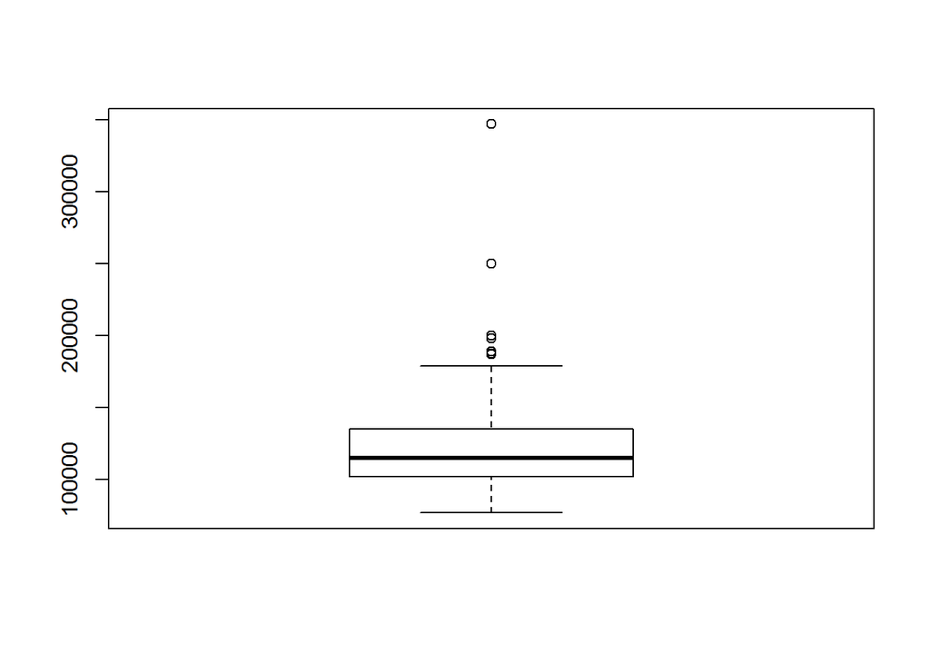

```r
boxplot(udata$Sale.Price)
```

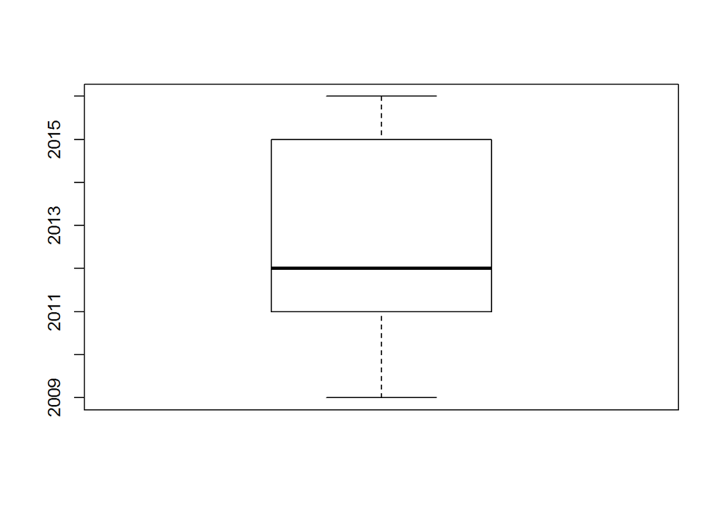

```r
boxplot(udata$Year.Sold)
```

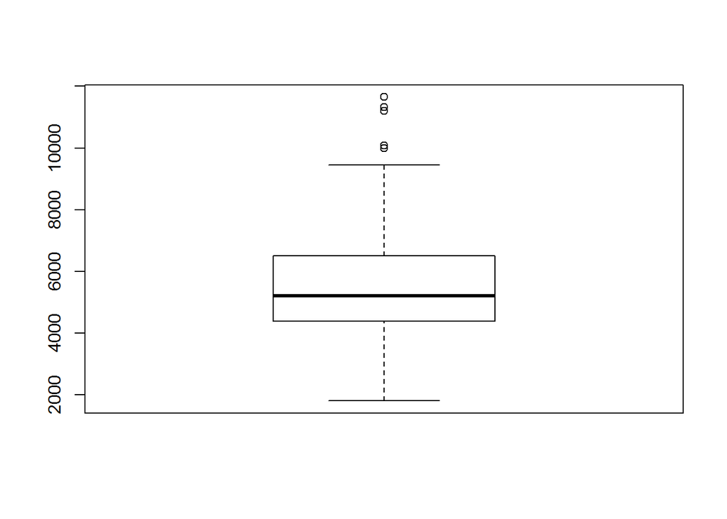

```r
boxplot(udata$Lot.Area)
```

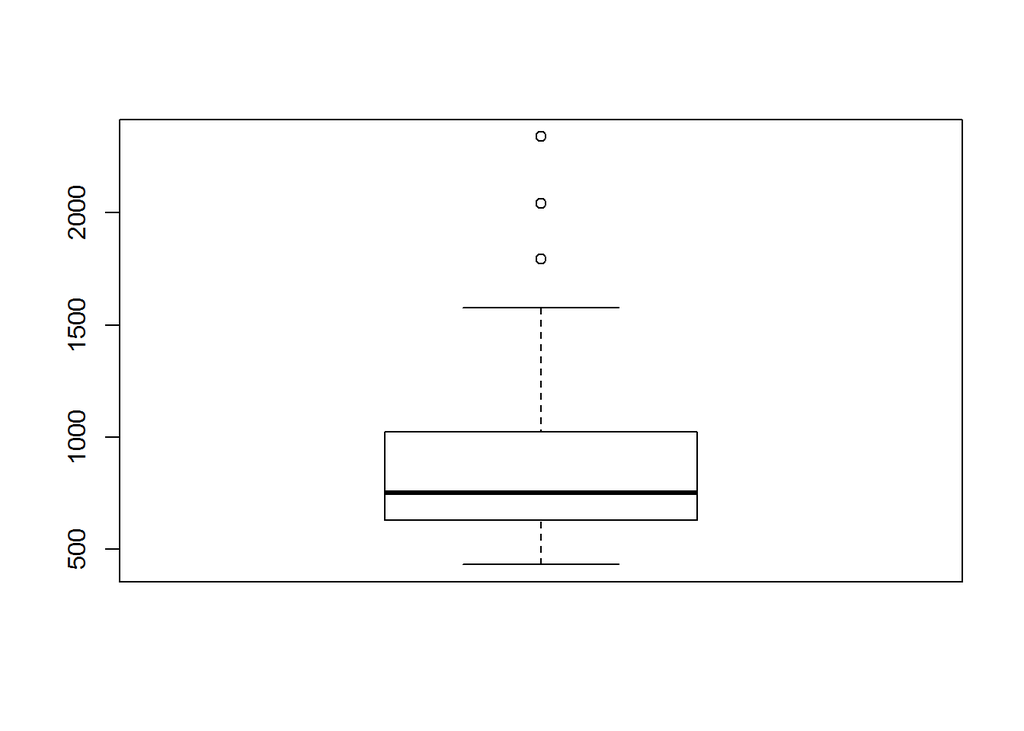

```r
boxplot(udata$Living.Area_SF)
```

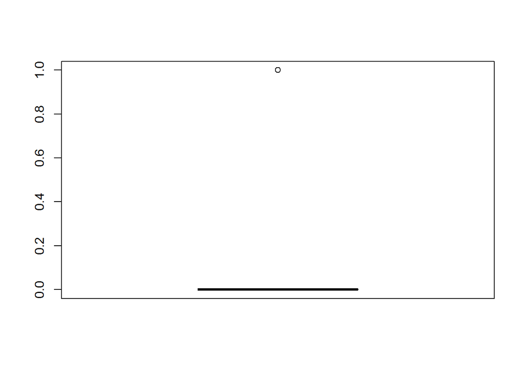

```r
boxplot(udata$UFFI.IN)
```

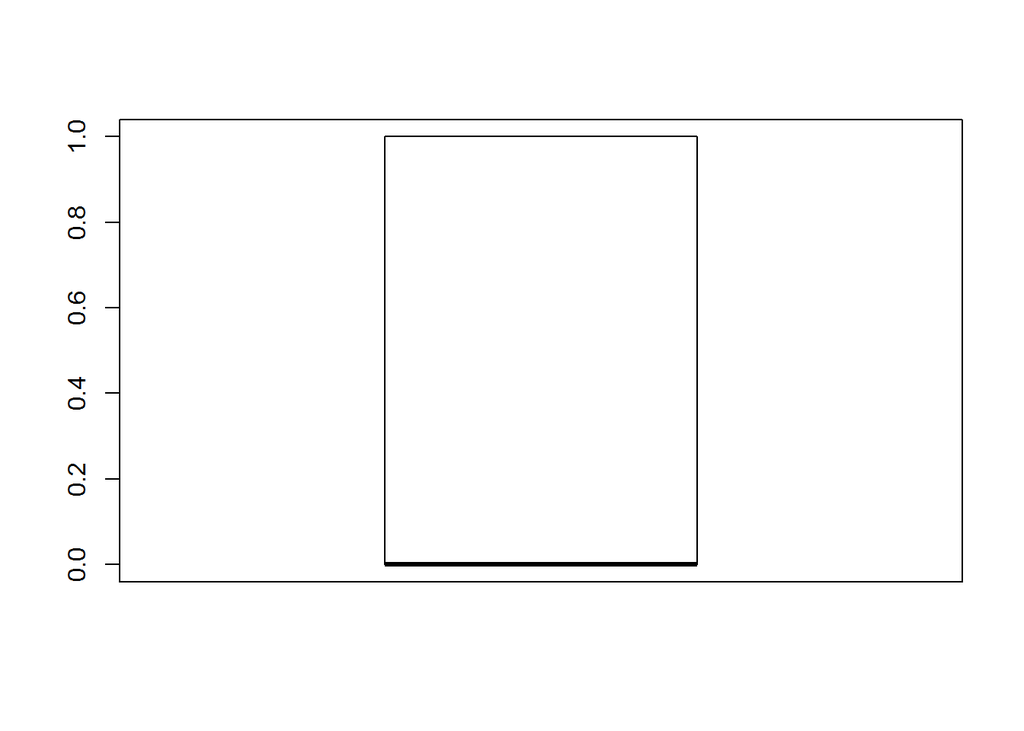

```r
boxplot(udata$Brick.Ext)
```

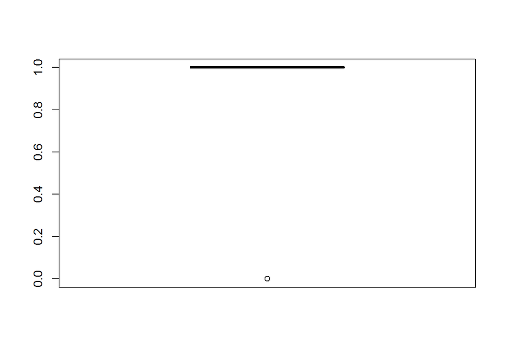

```r
boxplot(udata$X45.Yrs.)
```

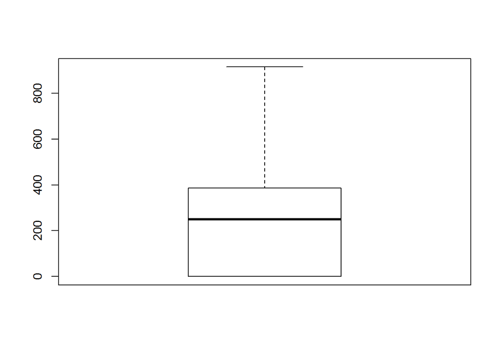

```r
boxplot(udata$Bsmnt.Fin_SF)
```

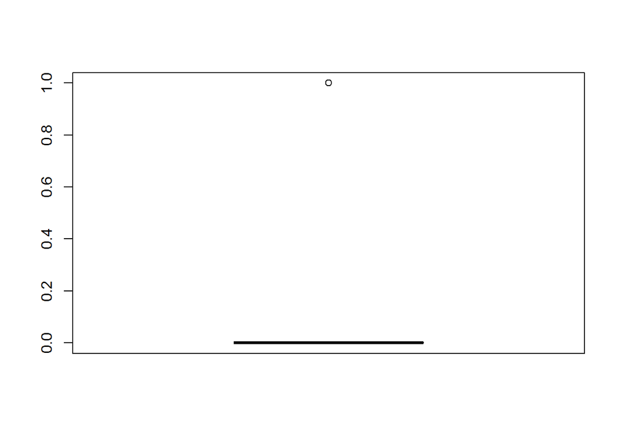

```r
boxplot(udata$Pool)
```

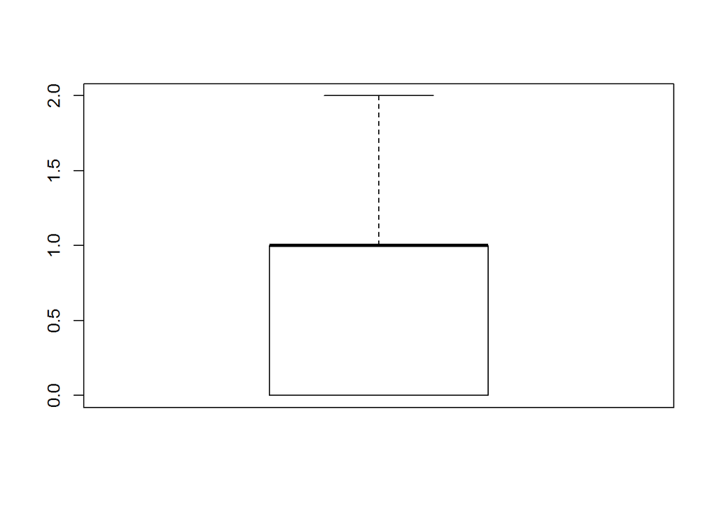

```r
boxplot(udata$Enc.Pk.Spaces)
```

Also, based on the data, lets find out the different corelations:

```r
cor(udata[c("Sale.Price","Year.Sold","Living.Area_SF","UFFI.IN","Brick.Ext","X45.Yrs.","Bsmnt.Fin_SF","Lot.Area","Enc.Pk.Spaces","Central.Air","Pool")])
```

```
##                Sale.Price   Year.Sold Living.Area_SF      UFFI.IN
## Sale.Price      1.0000000  0.56900042    0.723143670 -0.132346944
## Year.Sold       0.5690004  1.00000000    0.350935605 -0.229430163
## Living.Area_SF  0.7231437  0.35093560    1.000000000  0.044782629
## UFFI.IN        -0.1323469 -0.22943016    0.044782629  1.000000000
## Brick.Ext       0.2082198  0.19542319    0.143168175 -0.002966693
## X45.Yrs.       -0.2030637 -0.15002359    0.007512408  0.073288593
## Bsmnt.Fin_SF    0.1097338  0.10579778   -0.076706302 -0.062566193
## Lot.Area        0.4498596  0.27024264    0.394894002  0.162177296
## Enc.Pk.Spaces   0.4874032  0.26958765    0.390194693 -0.124012036
## Central.Air     0.2184656  0.04727103    0.162098868 -0.011732173
## Pool            0.4333188  0.11727196    0.188846345 -0.097248326
##                   Brick.Ext     X45.Yrs. Bsmnt.Fin_SF     Lot.Area
## Sale.Price      0.208219812 -0.203063703  0.109733802  0.449859639
## Year.Sold       0.195423193 -0.150023587  0.105797777  0.270242640
## Living.Area_SF  0.143168175  0.007512408 -0.076706302  0.394894002
## UFFI.IN        -0.002966693  0.073288593 -0.062566193  0.162177296
## Brick.Ext       1.000000000 -0.209519416 -0.084710312  0.007690759
## X45.Yrs.       -0.209519416  1.000000000 -0.468394189 -0.335551589
## Bsmnt.Fin_SF   -0.084710312 -0.468394189  1.000000000  0.219587126
## Lot.Area        0.007690759 -0.335551589  0.219587126  1.000000000
## Enc.Pk.Spaces  -0.045288666 -0.017212341 -0.009129915  0.268158441
## Central.Air     0.022815173 -0.139701051  0.295094502  0.288322835
## Pool           -0.021926450 -0.222222222  0.117456200  0.089901025
##                Enc.Pk.Spaces Central.Air        Pool
## Sale.Price       0.487403207  0.21846564  0.43331883
## Year.Sold        0.269587651  0.04727103  0.11727196
## Living.Area_SF   0.390194693  0.16209887  0.18884635
## UFFI.IN         -0.124012036 -0.01173217 -0.09724833
## Brick.Ext       -0.045288666  0.02281517 -0.02192645
## X45.Yrs.        -0.017212341 -0.13970105 -0.22222222
## Bsmnt.Fin_SF    -0.009129915  0.29509450  0.11745620
## Lot.Area         0.268158441  0.28832284  0.08990102
## Enc.Pk.Spaces    1.000000000  0.11641494  0.13425626
## Central.Air      0.116414944  1.00000000  0.03251662
## Pool             0.134256263  0.03251662  1.00000000
```

```r
udata1 <- subset(udata, Sale.Price<170000)
udata2 <- subset(udata1, Lot.Area < 10000)
udata3 <- subset(udata2, udata2$Living.Area_SF < 1600)

#Now lets get a summary of udata3
summary(udata3)
```

```
##   Observation      Year.Sold      Sale.Price        UFFI.IN
##  Min.   : 1.00   Min.   :2009   Min.   : 76900   Min.   :0.0000
##  1st Qu.:26.25   1st Qu.:2010   1st Qu.: 98600   1st Qu.:0.0000
##  Median :49.50   Median :2012   Median :112000   Median :0.0000
##  Mean   :48.72   Mean   :2012   Mean   :113198   Mean   :0.2209
##  3rd Qu.:72.75   3rd Qu.:2014   3rd Qu.:125750   3rd Qu.:0.0000
##  Max.   :99.00   Max.   :2016   Max.   :164000   Max.   :1.0000
##    Brick.Ext         X45.Yrs.       Bsmnt.Fin_SF      Lot.Area
##  Min.   :0.0000   Min.   :0.0000   Min.   :  0.0   Min.   :1800
##  1st Qu.:0.0000   1st Qu.:1.0000   1st Qu.:  0.0   1st Qu.:4293
##  Median :0.0000   Median :1.0000   Median :242.7   Median :4945
##  Mean   :0.3837   Mean   :0.8488   Mean   :243.9   Mean   :5252
##  3rd Qu.:1.0000   3rd Qu.:1.0000   3rd Qu.:383.8   3rd Qu.:6302
##  Max.   :1.0000   Max.   :1.0000   Max.   :915.1   Max.   :9450
##  Enc.Pk.Spaces    Living.Area_SF    Central.Air          Pool
##  Min.   :0.0000   Min.   : 431.9   Min.   :0.0000   Min.   :0.00000
##  1st Qu.:0.0000   1st Qu.: 625.7   1st Qu.:0.0000   1st Qu.:0.00000
##  Median :1.0000   Median : 731.6   Median :1.0000   Median :0.00000
##  Mean   :0.7093   Mean   : 772.6   Mean   :0.5349   Mean   :0.01163
##  3rd Qu.:1.0000   3rd Qu.: 884.9   3rd Qu.:1.0000   3rd Qu.:0.00000
##  Max.   :2.0000   Max.   :1464.9   Max.   :1.0000   Max.   :1.00000
```

##### 2b: Using visual analysis of the sales price with a histogram, is the data normally distributed and thus amenable to parametric statistical analysis? What are the correlations to the response variable and are there collinearities?

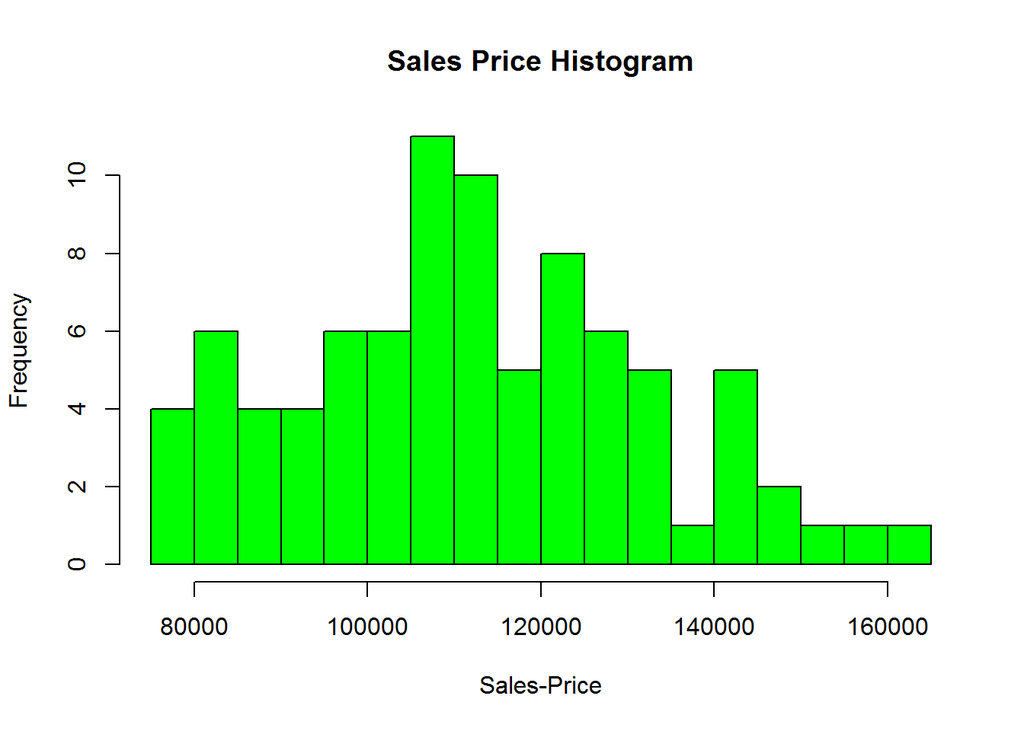

```r
library(ggplot2)
hist(udata3$Sale.Price, breaks=30, col="green", xlab="Sales-Price", main="Sales Price Histogram")  #using hist()
```

Lets develop the corelation for the new data:

```r
cor(udata3[c("Sale.Price","Year.Sold","UFFI.IN","Brick.Ext","X45.Yrs.","Bsmnt.Fin_SF","Lot.Area","Enc.Pk.Spaces","Central.Air","Living.Area_SF","Pool")])
```

```
##                 Sale.Price   Year.Sold      UFFI.IN   Brick.Ext
## Sale.Price      1.00000000  0.61935109 -0.320983270  0.20303793
## Year.Sold       0.61935109  1.00000000 -0.259271609  0.24368882
## UFFI.IN        -0.32098327 -0.25927161  1.000000000  0.04088093
## Brick.Ext       0.20303793  0.24368882  0.040880926  1.00000000
## X45.Yrs.       -0.10095259 -0.05453148 -0.010007956 -0.20103504
## Bsmnt.Fin_SF    0.14277918  0.07408431 -0.082611538 -0.01620570
## Lot.Area        0.18914865  0.10011512  0.052747439 -0.07380913
## Enc.Pk.Spaces   0.24699505  0.14222350 -0.155590516 -0.09189705
## Central.Air     0.08674728 -0.04882270 -0.009147553 -0.03121650
## Living.Area_SF  0.42976992  0.15165165  0.009915548  0.12565533
## Pool            0.04464409 -0.11054040 -0.057760366 -0.08558735
##                   X45.Yrs. Bsmnt.Fin_SF    Lot.Area Enc.Pk.Spaces
## Sale.Price     -0.10095259   0.14277918  0.18914865    0.24699505
## Year.Sold      -0.05453148   0.07408431  0.10011512    0.14222350
## UFFI.IN        -0.01000796  -0.08261154  0.05274744   -0.15559052
## Brick.Ext      -0.20103504  -0.01620570 -0.07380913   -0.09189705
## X45.Yrs.        1.00000000  -0.53463439 -0.35650303    0.11511354
## Bsmnt.Fin_SF   -0.53463439   1.00000000  0.38997280   -0.07576982
## Lot.Area       -0.35650303   0.38997280  1.00000000    0.14100213
## Enc.Pk.Spaces   0.11511354  -0.07576982  0.14100213    1.00000000
## Central.Air    -0.06810837   0.29884590  0.24538502    0.05107392
## Living.Area_SF  0.08333556  -0.14624284  0.07618938    0.05528043
## Pool           -0.25702791   0.12481659  0.08778658   -0.12284190
##                 Central.Air Living.Area_SF        Pool
## Sale.Price      0.086747276    0.429769917  0.04464409
## Year.Sold      -0.048822702    0.151651650 -0.11054040
## UFFI.IN        -0.009147553    0.009915548 -0.05776037
## Brick.Ext      -0.031216500    0.125655326 -0.08558735
## X45.Yrs.       -0.068108371    0.083335556 -0.25702791
## Bsmnt.Fin_SF    0.298845898   -0.146242836  0.12481659
## Lot.Area        0.245385023    0.076189377  0.08778658
## Enc.Pk.Spaces   0.051073925    0.055280426 -0.12284190
## Central.Air     1.000000000    0.042351724  0.10114435
## Living.Area_SF  0.042351724    1.000000000 -0.09620542
## Pool            0.101144347   -0.096205417  1.00000000
```

We find that various types of corelations exist, where some are highly corelated, others are not, and that some are positive and others are not.

Also, collinearities exist.

##### 2c: Is the presence or absence of UFFI alone enough to predict the value of a residential property?

UFFI is weakly corelated. As such, as a single parameter or alone, it is NOT enough to predict value of a residential property.

##### 2d: Is UFFI a significant predictor variable of selling price when taken with the full set of variables available?

The best way to determine it is to first develop a model:

```r
mod <- lm(udata3$Sale.Price ~ ., data=udata3)
summary(mod)
```

```
##
## Call:
## lm(formula = udata3$Sale.Price ~ ., data = udata3)
##
## Residuals:
##    Min     1Q Median     3Q    Max
## -37395  -7462  -1513   5498  54382
##
## Coefficients:
##                  Estimate Std. Error t value Pr(>|t|)
## (Intercept)    -9.297e+06  1.614e+06  -5.762 1.79e-07 ***
## Observation    -2.713e+01  7.118e+01  -0.381   0.7042
## Year.Sold       4.660e+03  8.025e+02   5.807 1.49e-07 ***
## UFFI.IN        -7.665e+03  3.883e+03  -1.974   0.0521 .
## Brick.Ext       3.393e+03  3.395e+03   0.999   0.3208
## X45.Yrs.       -8.901e+02  6.431e+03  -0.138   0.8903
## Bsmnt.Fin_SF    1.067e+01  8.296e+00   1.287   0.2022
## Lot.Area        4.802e-01  1.153e+00   0.417   0.6781
## Enc.Pk.Spaces   5.095e+03  2.526e+03   2.017   0.0474 *
## Living.Area_SF  3.424e+01  7.251e+00   4.722 1.08e-05 ***
## Central.Air     1.312e+03  3.274e+03   0.401   0.6898
## Pool            2.453e+04  1.485e+04   1.652   0.1028
## ---
## Signif. codes:  0 '***' 0.001 '**' 0.01 '*' 0.05 '.' 0.1 ' ' 1
##
## Residual standard error: 13810 on 74 degrees of freedom
## Multiple R-squared:  0.5968, Adjusted R-squared:  0.5369
## F-statistic: 9.959 on 11 and 74 DF,  p-value: 8.069e-11
```

Considering p-value for stepwise backward elimination method, with p<0.05; UFFI is not a significant predictor variable.

##### 2e: What is the ideal multiple regression model for predicting home prices in this data set? Provide a detailed analysis of the model, including Adjusted R-Squared, RMSE, and p-values of principal components. Use backfitting to build the model.

Lets first divide the data into training and test set. We will use createdatapartition() to divide data using caret package.

```r
library(caret);
set.seed(1234)
Index <- createDataPartition(y= udata3$Sale.Price, p=0.80, list=FALSE); #dividing the training and testing set into 80% and 20% respectively.

udata_train <- udata3[Index, ]; #creating training dataset
udata_test <- udata3[-Index, ]
```

Now we will train the model using the training data:

```r
uffi_model1 <- lm(Sale.Price ~ Year.Sold+UFFI.IN+Brick.Ext+X45.Yrs.+Bsmnt.Fin_SF+Lot.Area+Enc.Pk.Spaces+Living.Area_SF+Central.Air+Pool, data=udata_train)
summary(uffi_model1) #Lets see the summary of the model
```

```
##
## Call:
## lm(formula = Sale.Price ~ Year.Sold + UFFI.IN + Brick.Ext + X45.Yrs. +
##     Bsmnt.Fin_SF + Lot.Area + Enc.Pk.Spaces + Living.Area_SF +
##     Central.Air + Pool, data = udata_train)
##
## Residuals:
##    Min     1Q Median     3Q    Max
## -37970  -8268  -2182   7451  54616
##
## Coefficients: (1 not defined because of singularities)
##                  Estimate Std. Error t value Pr(>|t|)
## (Intercept)    -9.184e+06  1.871e+06  -4.910 7.16e-06 ***
## Year.Sold       4.603e+03  9.307e+02   4.946 6.26e-06 ***
## UFFI.IN        -7.887e+03  4.536e+03  -1.739 0.087108 .
## Brick.Ext       2.318e+03  4.143e+03   0.559 0.577974
## X45.Yrs.       -5.187e+01  6.251e+03  -0.008 0.993406
## Bsmnt.Fin_SF    1.077e+01  9.737e+00   1.106 0.273055
## Lot.Area        7.455e-01  1.284e+00   0.581 0.563631
## Enc.Pk.Spaces   4.632e+03  2.936e+03   1.578 0.119838
## Living.Area_SF  3.207e+01  8.494e+00   3.775 0.000365 ***
## Central.Air     1.491e+03  3.812e+03   0.391 0.697078
## Pool                   NA         NA      NA       NA
## ---
## Signif. codes:  0 '***' 0.001 '**' 0.01 '*' 0.05 '.' 0.1 ' ' 1
##
## Residual standard error: 14820 on 61 degrees of freedom
## Multiple R-squared:  0.5492, Adjusted R-squared:  0.4827
## F-statistic: 8.258 on 9 and 61 DF,  p-value: 6.483e-08
```

Now we will us stepwise backward elimination based on AIC using the step() function.

```r
step(lm(udata_train$Sale.Price ~ udata_train$Year.Sold + udata_train$UFFI.IN + udata_train$Brick.Ext + udata_train$X45.Yrs. + udata_train$Bsmnt.Fin_SF + udata_train$Lot.Area + udata_train$Enc.Pk.Spaces + udata_train$Living.Area_SF + udata_train$Central.Air + udata_train$Pool), direction = "backward")
```

```
## Start:  AIC=1372.91
## udata_train$Sale.Price ~ udata_train$Year.Sold + udata_train$UFFI.IN +
##     udata_train$Brick.Ext + udata_train$X45.Yrs. + udata_train$Bsmnt.Fin_SF +
##     udata_train$Lot.Area + udata_train$Enc.Pk.Spaces + udata_train$Living.Area_SF +
##     udata_train$Central.Air + udata_train$Pool
##
##
## Step:  AIC=1372.91
## udata_train$Sale.Price ~ udata_train$Year.Sold + udata_train$UFFI.IN +
##     udata_train$Brick.Ext + udata_train$X45.Yrs. + udata_train$Bsmnt.Fin_SF +
##     udata_train$Lot.Area + udata_train$Enc.Pk.Spaces + udata_train$Living.Area_SF +
##     udata_train$Central.Air
##
##                              Df  Sum of Sq        RSS    AIC
## - udata_train$X45.Yrs.        1      15113 1.3389e+10 1370.9
## - udata_train$Central.Air     1   33574896 1.3422e+10 1371.1
## - udata_train$Brick.Ext       1   68671170 1.3458e+10 1371.3
## - udata_train$Lot.Area        1   73995862 1.3463e+10 1371.3
## - udata_train$Bsmnt.Fin_SF    1  268503617 1.3657e+10 1372.3
## <none>                                     1.3389e+10 1372.9
## - udata_train$Enc.Pk.Spaces   1  546243880 1.3935e+10 1373.7
## - udata_train$UFFI.IN         1  663637883 1.4052e+10 1374.3
## - udata_train$Living.Area_SF  1 3128236594 1.6517e+10 1385.8
## - udata_train$Year.Sold       1 5369264577 1.8758e+10 1394.8
##
## Step:  AIC=1370.91
## udata_train$Sale.Price ~ udata_train$Year.Sold + udata_train$UFFI.IN +
##     udata_train$Brick.Ext + udata_train$Bsmnt.Fin_SF + udata_train$Lot.Area +
##     udata_train$Enc.Pk.Spaces + udata_train$Living.Area_SF +
##     udata_train$Central.Air
##
##                              Df  Sum of Sq        RSS    AIC
## - udata_train$Central.Air     1   34754786 1.3424e+10 1369.1
## - udata_train$Brick.Ext       1   77504028 1.3466e+10 1369.3
## - udata_train$Lot.Area        1   79079868 1.3468e+10 1369.3
## - udata_train$Bsmnt.Fin_SF    1  348413919 1.3737e+10 1370.7
## <none>                                     1.3389e+10 1370.9
## - udata_train$Enc.Pk.Spaces   1  547616470 1.3936e+10 1371.8
## - udata_train$UFFI.IN         1  663960427 1.4053e+10 1372.3
## - udata_train$Living.Area_SF  1 3128366683 1.6517e+10 1383.8
```

[output cut: 27 more lines]

```
## - udata_train$UFFI.IN         1  614058548 1.4115e+10 1368.7
## - udata_train$Living.Area_SF  1 3268907026 1.6770e+10 1380.9
## - udata_train$Year.Sold       1 6235542668 1.9736e+10 1392.5
##
## Step:  AIC=1365.93
## udata_train$Sale.Price ~ udata_train$Year.Sold + udata_train$UFFI.IN +
##     udata_train$Bsmnt.Fin_SF + udata_train$Enc.Pk.Spaces + udata_train$Living.Area_SF
##
##                              Df  Sum of Sq        RSS    AIC
## <none>                                     1.3584e+10 1365.9
## - udata_train$UFFI.IN         1  555258956 1.4139e+10 1366.8
## - udata_train$Enc.Pk.Spaces   1  599701035 1.4183e+10 1367.0
## - udata_train$Bsmnt.Fin_SF    1  687703939 1.4271e+10 1367.4
## - udata_train$Living.Area_SF  1 3661396592 1.7245e+10 1380.9
## - udata_train$Year.Sold       1 6481882588 2.0066e+10 1391.6
```

```
##
## Call:
## lm(formula = udata_train$Sale.Price ~ udata_train$Year.Sold +
##     udata_train$UFFI.IN + udata_train$Bsmnt.Fin_SF + udata_train$Enc.Pk.Spaces +
##     udata_train$Living.Area_SF)
##
## Coefficients:
##                (Intercept)       udata_train$Year.Sold
##                 -9.493e+06                   4.758e+03
##        udata_train$UFFI.IN    udata_train$Bsmnt.Fin_SF
##                 -7.017e+03                   1.363e+01
##  udata_train$Enc.Pk.Spaces  udata_train$Living.Area_SF
##                  4.707e+03                   3.370e+01
```

From the above elimination method, we get the the following final summary. Lets put it in a variable and find its summary to get the required detailed analysis of the summary:

```r
uffi_model_fin <- lm(formula = Sale.Price ~ Year.Sold + UFFI.IN + Bsmnt.Fin_SF + Enc.Pk.Spaces + Living.Area_SF, data = udata_train)
summary(uffi_model_fin)
```

```
##
## Call:
## lm(formula = Sale.Price ~ Year.Sold + UFFI.IN + Bsmnt.Fin_SF +
##     Enc.Pk.Spaces + Living.Area_SF, data = udata_train)
##
## Residuals:
##    Min     1Q Median     3Q    Max
## -41613  -7734  -1959   7322  52586
##
## Coefficients:
##                  Estimate Std. Error t value Pr(>|t|)
## (Intercept)    -9.493e+06  1.719e+06  -5.523 6.28e-07 ***
## Year.Sold       4.758e+03  8.544e+02   5.569 5.25e-07 ***
## UFFI.IN        -7.017e+03  4.305e+03  -1.630   0.1079
## Bsmnt.Fin_SF    1.363e+01  7.513e+00   1.814   0.0743 .
## Enc.Pk.Spaces   4.707e+03  2.778e+03   1.694   0.0951 .
## Living.Area_SF  3.370e+01  8.052e+00   4.186 8.72e-05 ***
## ---
## Signif. codes:  0 '***' 0.001 '**' 0.01 '*' 0.05 '.' 0.1 ' ' 1
##
## Residual standard error: 14460 on 65 degrees of freedom
## Multiple R-squared:  0.5427, Adjusted R-squared:  0.5075
## F-statistic: 15.43 on 5 and 65 DF,  p-value: 5.546e-10
```

So we find that Adjusted R2 is 0.5075.

Now lets find the predictiion on test data:

```r
pred_test <- predict(uffi_model_fin, udata_test)
```

Now we will have to find the RMSE on test set. We will use the following code:

```r
resid <- (udata_test$Sale.Price - pred_test)^2 #calculating residuals
meanresid <- mean(resid)  #Calculating the mean of the sqaured residuals
RMSE <- sqrt(meanresid)   #Calcualting the RMSE
RMSE
```

```
## [1] 9689.295
```

So the RMSE is 9689.295

##### 2f: On average, how do we expect UFFI will change the value of a property?

From the corelatiomn table that was earlier developed in 2b, UFFI negatively impacts the property value, since it is negatively corelated. So the presence of UFFI decreases the property value.

##### 2g: If the home in question is older than 45 years old, doesn’t have a finished basement, has a lot area of 5000 square feet, has a brick exterior, 2 enclosed parking spaces, 1700 square feet of living space, central air, and no pool, what is its predicted value and what are the 95% confidence intervals of this home with UFFI and without UFFI?

As such we will use the model: uffi_model_fin

Case1: With UFFI:-

```r
#case 1 - with UFFI and other given predictors

unk1 <- data.frame(100,2018,0,1,1,1,0,5000,2,1700,1,0) #We assume: home recently purchased | Year is 2018| Sales price is put 0 as the not dependent on it.
names(unk1) <- c("Observation", "Year.Sold", "Sale.Price","UFFI.IN","Brick.Ext", "X45.Yrs.", "Bsmnt.Fin_SF", "Lot.Area", "Enc.Pk.Spaces", "Living.Area_SF", "Central.Air", "Pool")
```

Lets calculate the sales price:

```r
unk1pred <- predict (uffi_model_fin, unk1)
unk1pred
```

```
##        1
## 169116.3
```

We find that the predicted sales price is 169116.3

Standard error from uffi_model_fin : 14460

Upper Limit with 95% confidence interval:

```r
ub <- 169116.3 + 1.96 * 14460
ub
```

```
## [1] 197457.9
```

Upper bound: 197457.9

Lower Limit with 95% confidence interval:

```r
lb <- 169116.3 - 1.96 * 14460
lb
```

```
## [1] 140774.7
```

Lower bound: 140774.7

Case 2 - with no UFFI and other given predictors

```r
unk2 <- data.frame(100,2018,0,0,1,1,0,5000,2,1700,1,0) #We assume: home recently purchased | Year is 2018| Sales price is put 0 as the not dependent on it.
names(unk2) <- c("Observation", "Year.Sold", "Sale.Price","UFFI.IN","Brick.Ext", "X45.Yrs.", "Bsmnt.Fin_SF", "Lot.Area", "Enc.Pk.Spaces", "Living.Area_SF", "Central.Air", "Pool")
```

Lets calculate the sales price:

```r
unk2pred <- predict (uffi_model_fin, unk2)
unk2pred
```

```
##        1
## 176132.9
```

We find that the predicted sales price is 176132.9

Standard error from uffi_model_fin : 14460

Upper limit with 95% confidence interval:

```r
ub2 <- 176132.9 + 1.96 * 14460
ub2
```

```
## [1] 204474.5
```

Upper bound: 204474.5

Lower Limit with 95% confidence interval:

```r
lb2 <- 176132.9 - 1.96 * 14460
lb2
```

```
## [1] 147791.3
```

lower limit: 147791.3

##### Problem 2h: If $215,000 was paid for this home, by how much, if any, did the client overpay, and how much compensation is justified due to overpayment?

Here basically we will be taking with UFFI, sothe overpaid price is:

```r
Predicted_price <- as.numeric(169116.3)
Paid_price <- as.numeric(215000)

Overpaid <- Paid_price - Predicted_price
Overpaid
```

```
## [1] 45883.7
```

The house was overpaid by: $45883.7

#### Problem3a: Divide the provided Titanic Survival Data into two subsets: a training data set and a test data set. Use whatever strategy you believe it best. Justify your answer.

Lets first read the file:

```r
titanic <- read.csv("titanic_data.csv", stringsAsFactors = FALSE, header = TRUE)
summary(titanic)
```

```
##   PassengerId       Survived          Pclass          Name
##  Min.   :  1.0   Min.   :0.0000   Min.   :1.000   Length:891
##  1st Qu.:223.5   1st Qu.:0.0000   1st Qu.:2.000   Class :character
##  Median :446.0   Median :0.0000   Median :3.000   Mode  :character
##  Mean   :446.0   Mean   :0.3838   Mean   :2.309
##  3rd Qu.:668.5   3rd Qu.:1.0000   3rd Qu.:3.000
##  Max.   :891.0   Max.   :1.0000   Max.   :3.000
##
##      Sex                 Age            SibSp           Parch
##  Length:891         Min.   : 0.42   Min.   :0.000   Min.   :0.0000
##  Class :character   1st Qu.:20.12   1st Qu.:0.000   1st Qu.:0.0000
##  Mode  :character   Median :28.00   Median :0.000   Median :0.0000
##                     Mean   :29.70   Mean   :0.523   Mean   :0.3816
##                     3rd Qu.:38.00   3rd Qu.:1.000   3rd Qu.:0.0000
##                     Max.   :80.00   Max.   :8.000   Max.   :6.0000
##                     NA's   :177
##     Ticket               Fare           Cabin             Embarked
##  Length:891         Min.   :  0.00   Length:891         Length:891
##  Class :character   1st Qu.:  7.91   Class :character   Class :character
##  Mode  :character   Median : 14.45   Mode  :character   Mode  :character
##                     Mean   : 32.20
##                     3rd Qu.: 31.00
##                     Max.   :512.33
##
```

Lets see if there are missing values:

```r
anyNA(titanic)
```

```
## [1] TRUE
```

We find that 20% in age column is missing. As such, we will not be able to remove the data. In this case, median is taken into consideration based on presence of outlier, while median is also a commonly accepted measure for imputing values.

```r
titanic$Age[is.na(titanic$Age)] <- median(titanic$Age, na.rm=T)
summary(titanic)
```

```
##   PassengerId       Survived          Pclass          Name
##  Min.   :  1.0   Min.   :0.0000   Min.   :1.000   Length:891
##  1st Qu.:223.5   1st Qu.:0.0000   1st Qu.:2.000   Class :character
##  Median :446.0   Median :0.0000   Median :3.000   Mode  :character
##  Mean   :446.0   Mean   :0.3838   Mean   :2.309
##  3rd Qu.:668.5   3rd Qu.:1.0000   3rd Qu.:3.000
##  Max.   :891.0   Max.   :1.0000   Max.   :3.000
##      Sex                 Age            SibSp           Parch
##  Length:891         Min.   : 0.42   Min.   :0.000   Min.   :0.0000
##  Class :character   1st Qu.:22.00   1st Qu.:0.000   1st Qu.:0.0000
##  Mode  :character   Median :28.00   Median :0.000   Median :0.0000
##                     Mean   :29.36   Mean   :0.523   Mean   :0.3816
##                     3rd Qu.:35.00   3rd Qu.:1.000   3rd Qu.:0.0000
##                     Max.   :80.00   Max.   :8.000   Max.   :6.0000
##     Ticket               Fare           Cabin             Embarked
##  Length:891         Min.   :  0.00   Length:891         Length:891
##  Class :character   1st Qu.:  7.91   Class :character   Class :character
##  Mode  :character   Median : 14.45   Mode  :character   Mode  :character
##                     Mean   : 32.20
##                     3rd Qu.: 31.00
##                     Max.   :512.33
```

We will need to create dummy variables. We will consider the following columns: Sex and Embark.

```r
#creating dummy variable for sex
titanic$sex_dummy <- ifelse(titanic$Sex == "male",1,0)

#creating dummy variables(2) for Emabark
titanic$Embarked_S <- ifelse(titanic$Embarked == "S",1,0)
titanic$Embarked_C <- ifelse(titanic$Embarked == "C",1,0)
```

Now we will divide the data into two sets of 0.8 and 0.2 partition using caret package:

```r
library(caret);   #load
set.seed(1234)
Index_titanic <- createDataPartition(y= titanic$Survived, p=0.80, list=FALSE);

train_titanic <- titanic [Index_titanic, ]; #creating training dataset
test_titanic <- titanic [-Index_titanic, ]   #creating training dataset

head(train_titanic)  #showing head of training set
```

```
##   PassengerId Survived Pclass
## 1           1        0      3
## 2           2        1      1
## 3           3        1      3
## 4           4        1      1
## 6           6        0      3
## 8           8        0      3
##                                                  Name    Sex Age SibSp
## 1                             Braund, Mr. Owen Harris   male  22     1
## 2 Cumings, Mrs. John Bradley (Florence Briggs Thayer) female  38     1
## 3                              Heikkinen, Miss. Laina female  26     0
## 4        Futrelle, Mrs. Jacques Heath (Lily May Peel) female  35     1
## 6                                    Moran, Mr. James   male  28     0
## 8                      Palsson, Master. Gosta Leonard   male   2     3
##   Parch           Ticket    Fare Cabin Embarked sex_dummy Embarked_S
## 1     0        A/5 21171  7.2500              S         1          1
## 2     0         PC 17599 71.2833   C85        C         0          0
## 3     0 STON/O2. 3101282  7.9250              S         0          1
## 4     0           113803 53.1000  C123        S         0          1
## 6     0           330877  8.4583              Q         1          0
## 8     1           349909 21.0750              S         1          1
##   Embarked_C
## 1          0
## 2          1
## 3          0
## 4          0
## 6          0
## 8          0
```

```r
head(test_titanic)  #showing head of testing set
```

```
##    PassengerId Survived Pclass                           Name    Sex Age
## 5            5        0      3       Allen, Mr. William Henry   male  35
## 7            7        0      1        McCarthy, Mr. Timothy J   male  54
## 13          13        0      3 Saundercock, Mr. William Henry   male  20
## 17          17        0      3           Rice, Master. Eugene   male   2
## 21          21        0      2           Fynney, Mr. Joseph J   male  35
## 23          23        1      3    McGowan, Miss. Anna "Annie" female  15
##    SibSp Parch    Ticket    Fare Cabin Embarked sex_dummy Embarked_S
## 5      0     0    373450  8.0500              S         1          1
## 7      0     0     17463 51.8625   E46        S         1          1
## 13     0     0 A/5. 2151  8.0500              S         1          1
## 17     4     1    382652 29.1250              Q         1          0
## 21     0     0    239865 26.0000              S         1          1
## 23     0     0    330923  8.0292              Q         0          0
##    Embarked_C
## 5           0
## 7           0
## 13          0
## 17          0
## 21          0
## 23          0
```

Thus we have our training and test set.

##### 3b: Construct a logistic regression model to predict the probability of a passenger surviving the Titanic accident. Test the statistical significance of all parameters and eliminate those that have a p-value > 0.05 using stepwise backward elimination.

Lets first develop model with every parameters:

```r
Model_titanic <- glm(Survived ~ Pclass+sex_dummy+Age+SibSp+Parch+Fare+Embarked_S+Embarked_C, data= train_titanic, family= binomial) #glm function is used to train. family = binomial.

summary(Model_titanic)
```

```
##
## Call:
## glm(formula = Survived ~ Pclass + sex_dummy + Age + SibSp + Parch +
##     Fare + Embarked_S + Embarked_C, family = binomial, data = train_titanic)
##
## Deviance Residuals:
##     Min       1Q   Median       3Q      Max
## -2.4763  -0.5629  -0.4095   0.5994   2.4778
##
## Coefficients:
##              Estimate Std. Error z value Pr(>|z|)
## (Intercept)  5.386444   0.733732   7.341 2.12e-13 ***
## Pclass      -1.203077   0.165078  -7.288 3.15e-13 ***
## sex_dummy   -2.768124   0.227664 -12.159  < 2e-16 ***
## Age         -0.041493   0.008851  -4.688 2.76e-06 ***
## SibSp       -0.286471   0.114882  -2.494   0.0126 *
## Parch       -0.027605   0.133030  -0.208   0.8356
## Fare         0.002920   0.002815   1.037   0.2996
## Embarked_S  -0.228733   0.373877  -0.612   0.5407
## Embarked_C  -0.081072   0.430553  -0.188   0.8506
## ---
## Signif. codes:  0 '***' 0.001 '**' 0.01 '*' 0.05 '.' 0.1 ' ' 1
##
## (Dispersion parameter for binomial family taken to be 1)
##
##     Null deviance: 945.03  on 712  degrees of freedom
## Residual deviance: 615.53  on 704  degrees of freedom
## AIC: 633.53
##
## Number of Fisher Scoring iterations: 5
```

Removing Embarked_c

```r
Model_titanic_2 <- glm(Survived ~ Pclass+sex_dummy+Age+SibSp+Parch+Fare+Embarked_S, data= train_titanic, family= binomial) #glm function is used to train. family = binomial.

summary(Model_titanic_2)
```

```
##
## Call:
## glm(formula = Survived ~ Pclass + sex_dummy + Age + SibSp + Parch +
##     Fare + Embarked_S, family = binomial, data = train_titanic)
##
## Deviance Residuals:
##     Min       1Q   Median       3Q      Max
## -2.4712  -0.5625  -0.4079   0.5998   2.4751
##
## Coefficients:
##              Estimate Std. Error z value Pr(>|z|)
## (Intercept)  5.316287   0.631190   8.423  < 2e-16 ***
## Pclass      -1.196411   0.161162  -7.424 1.14e-13 ***
## sex_dummy   -2.771769   0.226976 -12.212  < 2e-16 ***
## Age         -0.041368   0.008825  -4.687 2.77e-06 ***
## SibSp       -0.286714   0.114987  -2.493   0.0127 *
## Parch       -0.029541   0.132656  -0.223   0.8238
## Fare         0.002893   0.002813   1.028   0.3038
## Embarked_S  -0.173130   0.229844  -0.753   0.4513
## ---
## Signif. codes:  0 '***' 0.001 '**' 0.01 '*' 0.05 '.' 0.1 ' ' 1
##
## (Dispersion parameter for binomial family taken to be 1)
##
##     Null deviance: 945.03  on 712  degrees of freedom
## Residual deviance: 615.56  on 705  degrees of freedom
## AIC: 631.56
##
## Number of Fisher Scoring iterations: 5
```

Removing parch:

```r
Model_titanic_3 <- glm(Survived ~ Pclass+sex_dummy+Age+SibSp+Fare+Embarked_S, data= train_titanic, family= binomial) #glm function is used to train. family = binomial.

summary(Model_titanic_3)
```

```
##
## Call:
## glm(formula = Survived ~ Pclass + sex_dummy + Age + SibSp + Fare +
##     Embarked_S, family = binomial, data = train_titanic)
##
## Deviance Residuals:
##     Min       1Q   Median       3Q      Max
## -2.4808  -0.5603  -0.4082   0.6020   2.4767
##
## Coefficients:
##              Estimate Std. Error z value Pr(>|z|)
## (Intercept)  5.313387   0.630263   8.430  < 2e-16 ***
## Pclass      -1.200231   0.160100  -7.497 6.54e-14 ***
## sex_dummy   -2.761254   0.221785 -12.450  < 2e-16 ***
## Age         -0.041268   0.008810  -4.684 2.81e-06 ***
## SibSp       -0.293068   0.111550  -2.627  0.00861 **
## Fare         0.002761   0.002728   1.012  0.31147
## Embarked_S  -0.176865   0.229160  -0.772  0.44023
## ---
## Signif. codes:  0 '***' 0.001 '**' 0.01 '*' 0.05 '.' 0.1 ' ' 1
##
## (Dispersion parameter for binomial family taken to be 1)
##
##     Null deviance: 945.03  on 712  degrees of freedom
## Residual deviance: 615.61  on 706  degrees of freedom
## AIC: 629.61
##
## Number of Fisher Scoring iterations: 5
```

Removing Embarked_S:

```r
Model_titanic_4 <- glm(Survived ~ Pclass+sex_dummy+Age+SibSp+Fare, data= train_titanic, family= binomial) #glm function is used to train. family = binomial.

summary(Model_titanic_4)
```

```
##
## Call:
## glm(formula = Survived ~ Pclass + sex_dummy + Age + SibSp + Fare,
##     family = binomial, data = train_titanic)
##
## Deviance Residuals:
##     Min       1Q   Median       3Q      Max
## -2.5165  -0.5544  -0.4018   0.6029   2.4608
##
## Coefficients:
##              Estimate Std. Error z value Pr(>|z|)
## (Intercept)  5.192753   0.608663   8.531  < 2e-16 ***
## Pclass      -1.195730   0.159853  -7.480 7.42e-14 ***
## sex_dummy   -2.779593   0.221059 -12.574  < 2e-16 ***
## Age         -0.041566   0.008806  -4.720 2.36e-06 ***
## SibSp       -0.306666   0.110719  -2.770  0.00561 **
## Fare         0.003115   0.002701   1.153  0.24878
## ---
## Signif. codes:  0 '***' 0.001 '**' 0.01 '*' 0.05 '.' 0.1 ' ' 1
##
## (Dispersion parameter for binomial family taken to be 1)
##
##     Null deviance: 945.03  on 712  degrees of freedom
## Residual deviance: 616.21  on 707  degrees of freedom
## AIC: 628.21
##
## Number of Fisher Scoring iterations: 5
```

Removing fare:

```r
Model_titanic_5 <- glm(Survived ~ Pclass+sex_dummy+Age+SibSp, data= train_titanic, family= binomial) #glm function is used to train. family = binomial.

summary(Model_titanic_5)
```

```
##
## Call:
## glm(formula = Survived ~ Pclass + sex_dummy + Age + SibSp, family = binomial,
##     data = train_titanic)
##
## Deviance Residuals:
##     Min       1Q   Median       3Q      Max
## -2.4228  -0.5534  -0.4000   0.5896   2.4694
##
## Coefficients:
##             Estimate Std. Error z value Pr(>|z|)
## (Intercept)  5.50364    0.55042   9.999  < 2e-16 ***
## Pclass      -1.28887    0.13963  -9.230  < 2e-16 ***
## sex_dummy   -2.78835    0.22095 -12.620  < 2e-16 ***
## Age         -0.04202    0.00878  -4.787  1.7e-06 ***
## SibSp       -0.28369    0.10895  -2.604  0.00922 **
## ---
## Signif. codes:  0 '***' 0.001 '**' 0.01 '*' 0.05 '.' 0.1 ' ' 1
##
## (Dispersion parameter for binomial family taken to be 1)
##
##     Null deviance: 945.03  on 712  degrees of freedom
## Residual deviance: 617.71  on 708  degrees of freedom
## AIC: 627.71
##
## Number of Fisher Scoring iterations: 5
```

Thus we get our final model after stepwise backward elimination method.

##### 3c: State the model as a regression equation.

We derive the regression equation from the intercepts and the coefficients of the models summary.

The above model (Model_titanic_5) can be written as:

```r
#f(x)= 1/(1+e^-(5.50364 - 1.28887 * Pclass - 2.78835 * sex_dummy - 0.04202 * Age - 0.28369 * SibSp))
```

##### 3d: Test the model against the test data set and determine its prediction accuracy (as a percentage correct).

So we need to determine prediction accuracy from the test set. Our final model based on which we will use our predict function is:MOdel_titanic5

```r
# find the predictions - using the final model(MOdel_titanic5)

pred_titanic <-  predict(Model_titanic_5, test_titanic, type= "response" )
#We will pass two arguments to the table: Actual value, and predicted value(condition > 0.5)
(table(ActualValue = test_titanic$Survived , PredictedValue =pred_titanic>0.5))
```

```
##            PredictedValue
## ActualValue FALSE TRUE
##           0    83   22
##           1    20   53
```

We find our accuracy as:

```r
accuracy_titanic <- (83 + 53)/(83+53+22+20)
accuracy_titanic
```

```
## [1] 0.7640449
```

Our accuracy is 76.4%

#### Problem4: Elaborate on the use of kNN and Naive Bayes for data imputation. Explain in reasonable detail how you would use these algorithms to impute missing data and why it can work.

Imputing missing value plays a major role in model development. Finding a dataset without the missing values is very rare. When there are missing values in a dataset, it can lead to skewness, bias, etc, ultimately causing improper model development. In a world which is progressing in the field of machine learning at a lightning speed, it is more than ever important to treat data, and especially missing values. Missing values can be due to various factors: both human error, or technical, and in some cases, because it is unknown.

There are various ways in which we can impute data: mean, median, mode, knn, naive bayes, etc. Here we will focus on imputing data using two of the algorithms: Knn and Naive Bayes.

K-NN: K-NN forms different clusters based on the different parameters other than the missing value. Now, based on the other features of the missing value component, it measures euclidean distance to all parameters, and assigns the nearest cluster value component to the missing value. One of the main features of using knn is it works with both categorical and numerical features, and as such, it is often considered a powerful imputation algorithm. This is basically predicting the missing value by training the missing value attribute against the other attributes. K is user defined, although in many cases, sqrt(n) where n is the number of rows of the dataset is considered. User also needs to define the type of distance that is nrequired to calculate the K nearest neighbors.

Naive Bayes: Naive Bayes is also another powerfool algorithm for data imputation. The model basically uses bayesian equation to form probability to determine the missing value. It treats missing value attribute as a class attribute. In the first step, training and testing sets are divided into classes, where those instances that have missing value are basically training set, while the others as testing. It follows one after another, each getting imputed by the basis of other parameters, until all the missing values is imputed. When in comparison with Knn, it is considered a better fit for imputed data for production model as it takes the probability estimation route, unlike knn which is a lazy classifier.

Sources: Machine Learning with R - Second Edition http://r-statistics.co/Outlier-Treatment-With-R.html www.stackoverflow.com https://www.analyticsvidhya.com